# NETFLIX ANALYSIS

### **Inspect Data**

```python
df.head(10)
```

|  | show_id | type | movie name | director | cast | country | date_added | release_year | rating | duration | listed_in | summary | rating_category |
| --- | --- | --- | --- | --- | --- | --- | --- | --- | --- | --- | --- | --- | --- |
| 0 | s1 | Movie | Dick Johnson Is Dead | Kirsten Johnson | unknown | United States | 2021-09-25 | 2020 | PG-13 | 90 min | Documentaries | As her father nears the end of his life, filmm... | Teen |
| 1 | s2 | TV Show | Blood & Water | unknown | Ama Qamata, Khosi Ngema, Gail Mabalane, Thaban... | South Africa | 2021-09-24 | 2021 | TV-MA | 2 Seasons | International TV Shows, TV Dramas, TV Mysteries | After crossing paths at a party, a Cape Town t... | Adult |
| 2 | s3 | TV Show | Ganglands | Julien Leclercq | Sami Bouajila, Tracy Gotoas, Samuel Jouy, Nabi... | unknown | 2021-09-24 | 2021 | TV-MA | 1 Season | Crime TV Shows, International TV Shows, TV Act... | To protect his family from a powerful drug lor... | Adult |
| 3 | s4 | TV Show | Jailbirds New Orleans | unknown | unknown | unknown | 2021-09-24 | 2021 | TV-MA | 1 Season | Docuseries, Reality TV | Feuds, flirtations and toilet talk go down amo... | Adult |
| 4 | s5 | TV Show | Kota Factory | unknown | Mayur More, Jitendra Kumar, Ranjan Raj, Alam K... | India | 2021-09-24 | 2021 | TV-MA | 2 Seasons | International TV Shows, Romantic TV Shows, TV ... | In a city of coaching centers known to train I... | Adult |
| 5 | s6 | TV Show | Midnight Mass | Mike Flanagan | Kate Siegel, Zach Gilford, Hamish Linklater, H... | unknown | 2021-09-24 | 2021 | TV-MA | 1 Season | TV Dramas, TV Horror, TV Mysteries | The arrival of a charismatic young priest brin... | Adult |
| 6 | s7 | Movie | My Little Pony: A New Generation | Robert Cullen, José Luis Ucha | Vanessa Hudgens, Kimiko Glenn, James Marsden, ... | unknown | 2021-09-24 | 2021 | PG | 91 min | Children & Family Movies | Equestria's divided. But a bright-eyed hero be... | Family |
| 7 | s8 | Movie | Sankofa | Haile Gerima | Kofi Ghanaba, Oyafunmike Ogunlano, Alexandra D... | United States, Ghana, Burkina Faso, United Kin... | 2021-09-24 | 1993 | TV-MA | 125 min | Dramas, Independent Movies, International Movies | On a photo shoot in Ghana, an American model s... | Adult |
| 8 | s9 | TV Show | The Great British Baking Show | Andy Devonshire | Mel Giedroyc, Sue Perkins, Mary Berry, Paul Ho... | United Kingdom | 2021-09-24 | 2021 | TV-14 | 9 Seasons | British TV Shows, Reality TV | A talented batch of amateur bakers face off in... | Teen |
| 9 | s10 | Movie | The Starling | Theodore Melfi | Melissa McCarthy, Chris O'Dowd, Kevin Kline, T... | United States | 2021-09-24 | 2021 | PG-13 | 104 min | Comedies, Dramas | A woman adjusting to life after a loss contend... | Teen |

```python
df.tail(10)
```

|  | show_id | type | movie name | director | cast | country | date_added | release_year | rating | duration | listed_in | summary | rating_category |
| --- | --- | --- | --- | --- | --- | --- | --- | --- | --- | --- | --- | --- | --- |
| 8780 | s8798 | TV Show | Zak Storm | unknown | Michael Johnston, Jessica Gee-George, Christin... | United States, France, South Korea, Indonesia | 2018-09-13 | 2016 | TV-Y7 | 3 Seasons | Kids' TV | Teen surfer Zak Storm is mysteriously transpor... | Kids |
| 8781 | s8799 | Movie | Zed Plus | Chandra Prakash Dwivedi | Adil Hussain, Mona Singh, K.K. Raina, Sanjay M... | India | 2019-12-31 | 2014 | TV-MA | 131 min | Comedies, Dramas, International Movies | A philandering small-town mechanic's political... | Adult |
| 8782 | s8800 | Movie | Zenda | Avadhoot Gupte | Santosh Juvekar, Siddharth Chandekar, Sachit P... | India | 2018-02-15 | 2009 | TV-14 | 120 min | Dramas, International Movies | A change in the leadership of a political part... | Teen |
| 8783 | s8801 | TV Show | Zindagi Gulzar Hai | unknown | Sanam Saeed, Fawad Khan, Ayesha Omer, Mehreen ... | Pakistan | 2016-12-15 | 2012 | TV-PG | 1 Season | International TV Shows, Romantic TV Shows, TV ... | Strong-willed, middle-class Kashaf and carefre... | Family |
| 8784 | s8802 | Movie | Zinzana | Majid Al Ansari | Ali Suliman, Saleh Bakri, Yasa, Ali Al-Jabri, ... | United Arab Emirates, Jordan | 2016-03-09 | 2015 | TV-MA | 96 min | Dramas, International Movies, Thrillers | Recovering alcoholic Talal wakes up inside a s... | Adult |
| 8785 | s8803 | Movie | Zodiac | David Fincher | Mark Ruffalo, Jake Gyllenhaal, Robert Downey J... | United States | 2019-11-20 | 2007 | R | 158 min | Cult Movies, Dramas, Thrillers | A political cartoonist, a crime reporter and a... | Adult |
| 8786 | s8804 | TV Show | Zombie Dumb | unknown | unknown | unknown | 2019-07-01 | 2018 | TV-Y7 | 2 Seasons | Kids' TV, Korean TV Shows, TV Comedies | While living alone in a spooky town, a young g... | Kids |
| 8787 | s8805 | Movie | Zombieland | Ruben Fleischer | Jesse Eisenberg, Woody Harrelson, Emma Stone, ... | United States | 2019-11-01 | 2009 | R | 88 min | Comedies, Horror Movies | Looking to survive in a world taken over by zo... | Adult |
| 8788 | s8806 | Movie | Zoom | Peter Hewitt | Tim Allen, Courteney Cox, Chevy Chase, Kate Ma... | United States | 2020-01-11 | 2006 | PG | 88 min | Children & Family Movies, Comedies | Dragged from civilian life, a former superhero... | Family |
| 8789 | s8807 | Movie | Zubaan | Mozez Singh | Vicky Kaushal, Sarah-Jane Dias, Raaghav Chanan... | India | 2019-03-02 | 2015 | TV-14 | 111 min | Dramas, International Movies, Music & Musicals | A scrappy but poor boy worms his way into a ty... | Teen |

```python
df.sample(20)
```

|  | show_id | type | movie name | director | cast | country | date_added | release_year | rating | duration | listed_in | summary | rating_category |
| --- | --- | --- | --- | --- | --- | --- | --- | --- | --- | --- | --- | --- | --- |
| 4313 | s4314 | Movie | Out of Many, One | John Hoffman, Nanfu Wang | unknown | United States | 2018-12-12 | 2018 | TV-PG | 35 min | Documentaries | In this documentary short, a diverse group of ... | Family |
| 4663 | s4664 | TV Show | Quantico | unknown | Priyanka Chopra, Josh Hopkins, Jake McLaughlin... | United States | 2018-09-02 | 2018 | TV-14 | 3 Seasons | Crime TV Shows, TV Dramas, TV Mysteries | When evidence in a deadly terrorist attack imp... | Teen |
| 6799 | s6808 | Movie | From Japan to Egypt | Mahmoud Karim | Ahmed Eid, Saki Tsukamoto, Nada Moussa, Mohamm... | Egypt | 2019-06-06 | 2017 | TV-14 | 93 min | Children & Family Movies, Comedies, Dramas | After his wife relocates to her home country o... | Teen |
| 7932 | s7949 | TV Show | Save Our Shelter | unknown | Rocky Kanaka, Rob North | United States | 2018-08-18 | 2015 | TV-G | 1 Season | Reality TV | Pet rescue expert Rocky Kanaka and renovation ... | Family |
| 4213 | s4214 | Movie | El Potro: Unstoppable | Lorena Munoz | Jimena Barón, Rodrigo Romero, Diego Cremonesi,... | unknown | 2019-01-04 | 2018 | TV-MA | 122 min | Dramas, International Movies, Music & Musicals | Argentine cuarteto singer Rodrigo "El Potro" B... | Adult |
| 6923 | s6934 | Movie | Harry and Snowman | Ron Davis | Harry DeLeyer | United States | 2017-01-15 | 2015 | TV-PG | 83 min | Documentaries, Sports Movies | With only a strong will and a cheap horse, a f... | Family |
| 4445 | s4446 | Movie | Kai Po Che! | Abhishek Kapoor | Rajkummar Rao, Amit Sadh, Sushant Singh Rajput... | India | 2018-11-01 | 2013 | TV-MA | 120 min | Dramas, International Movies, Sports Movies | This Bollywood drama tells the story of three ... | Adult |
| 5053 | s5054 | Movie | Newness | Drake Doremus | Nicholas Hoult, Laia Costa, Danny Huston, Cour... | United States | 2018-02-01 | 2017 | TV-MA | 117 min | Dramas, Independent Movies, Romantic Movies | Martin and Gabi try to form a relationship aft... | Adult |
| 8216 | s8234 | Movie | The Bygone | Graham Phillips, Parker Phillips | Graham Phillips, Shawn Hatosy, Jamie McShane, ... | United States | 2020-03-23 | 2019 | TV-MA | 106 min | Independent Movies, Thrillers | His way of life under threat due to the oil fr... | Adult |
| 2277 | s2278 | Movie | Madras Café | Shoojit Sircar | John Abraham, Nargis Fakhri, Rashi Khanna, Avi... | India | 2020-07-05 | 2013 | TV-14 | 128 min | Dramas, International Movies, Thrillers | An Indian intelligence agent journeys to a war... | Teen |
| 4551 | s4552 | TV Show | Monty Python's Flying Circus | unknown | John Cleese, Graham Chapman, Terry Jones, Eric... | United Kingdom | 2018-10-02 | 1974 | TV-14 | 4 Seasons | British TV Shows, Classic & Cult TV, Internati... | The Monty Python players make their mark with ... | Teen |
| 6188 | s6195 | TV Show | Atomic Puppet | unknown | Eric Bauza, Lisa Norton, Carlos Díaz, Peter Ol... | Canada, France | 2017-12-01 | 2016 | TV-Y7 | 1 Season | Crime TV Shows, Kids' TV, TV Comedies | Captain Atomic – once a superhero, now a sock ... | Kids |
| 1789 | s1790 | Movie | Secrets of the Saqqara Tomb | James Tovell | unknown | United States | 2020-10-28 | 2020 | TV-PG | 114 min | Documentaries | After unearthing a tomb that had been untouche... | Family |
| 7637 | s7653 | Movie | On Yoga The Architecture of Peace | Heitor Dhalia | Michael O’Neill | Brazil, India, China, United States | 2018-01-10 | 2017 | TV-14 | 92 min | Documentaries, Faith & Spirituality | Based on photographer Michael O’Neill’s book o... | Teen |
| 7553 | s7569 | TV Show | Nature: Animals With Cameras | unknown | Gordon Buchanan | United Kingdom, United States | 2018-10-01 | 2018 | TV-PG | 1 Season | Docuseries, Science & Nature TV | With custom-built cameras attached to their bo... | Family |
| 79 | s80 | Movie | Tughlaq Durbar (Telugu) | Delhiprasad Deenadayalan | Vijay Sethupathi, Parthiban, Raashi Khanna | unknown | 2021-09-11 | 2021 | TV-14 | 145 min | Comedies, Dramas, International Movies | A budding politician has devious plans to rise... | Teen |
| 6174 | s6181 | Movie | Apollo 18 | Gonzalo López-Gallego | Warren Christie, Lloyd Owen, Ryan Robbins, Mic... | United States, Canada | 2019-03-09 | 2011 | PG-13 | 87 min | Horror Movies, Sci-Fi & Fantasy, Thrillers | This sci-fi thriller suggests that Apollo 17, ... | Teen |
| 1982 | s1983 | Movie | Anaamika | Sekhar Kammula | Nayantara, Vaibhav Reddy, Pasupathy, Harshvard... | India | 2020-09-17 | 2014 | TV-14 | 130 min | International Movies, Thrillers | As a woman scours Hyderabad for her missing hu... | Teen |
| 1107 | s1108 | Movie | God Calling | BB Sasore | Zainab Balogun, Karibi Fubara, Diana Egwuatu, ... | Nigeria | 2021-04-02 | 2018 | TV-MA | 120 min | Dramas, Faith & Spirituality, International Mo... | The loss of a child plunges Sade into a suicid... | Adult |
| 5747 | s5749 | Movie | Bleach The Movie: Fade to Black | Noriyuki Abe | Masakazu Morita, Fumiko Orikasa, Aya Hirano, H... | Japan | 2016-10-15 | 2008 | TV-PG | 94 min | Action & Adventure, Anime Features, Sci-Fi & F... | When his mind is fogged by a scimitar-weilding... | Family |

### **Check Column Data Type**

```python
df.dtypes
```

```
show_id            object
type               object
movie name         object
director           object
cast               object
country            object
date_added         object
release_year        int64
rating             object
duration           object
listed_in          object
summary            object
rating_category    object
dtype: object
```

### **Display Column Names**

```python
df.columns
```

```
Index(['show_id', 'type', 'movie name', 'director', 'cast', 'country',
       'date_added', 'release_year', 'rating', 'duration', 'listed_in',
       'summary', 'rating_category'],
      dtype='object')
```

### **Display Number Of Rows And Columns**

```python
df.shape
```

```
(8790, 13)
```

```python
df.info()
```

```
<class 'pandas.core.frame.DataFrame'>
RangeIndex: 8790 entries, 0 to 8789
Data columns (total 13 columns):
 #   Column           Non-Null Count  Dtype
---  ------           --------------  -----
 0   show_id          8790 non-null   object
 1   type             8790 non-null   object
 2   movie name       8790 non-null   object
 3   director         8790 non-null   object
 4   cast             8790 non-null   object
 5   country          8790 non-null   object
 6   date_added       8790 non-null   object
 7   release_year     8790 non-null   int64
 8   rating           8790 non-null   object
 9   duration         8790 non-null   object
 10  listed_in        8790 non-null   object
 11  summary          8790 non-null   object
 12  rating_category  8790 non-null   object
dtypes: int64(1), object(12)
memory usage: 892.9+ KB
```

## selecting columns

```python
df["type"]
```

```
0         Movie
1       TV Show
2       TV Show
3       TV Show
4       TV Show
         ...
8785      Movie
8786    TV Show
8787      Movie
8788      Movie
8789      Movie
Name: type, Length: 8790, dtype: object
```

```python
df["duration"]
```

```
0          90 min
1       2 Seasons
2        1 Season
3        1 Season
4       2 Seasons
          ...
8785      158 min
8786    2 Seasons
8787       88 min
8788       88 min
8789      111 min
Name: duration, Length: 8790, dtype: object
```

```python
df["rating"]
```

```
0       PG-13
1       TV-MA
2       TV-MA
3       TV-MA
4       TV-MA
        ...
8785        R
8786    TV-Y7
8787        R
8788       PG
8789    TV-14
Name: rating, Length: 8790, dtype: object
```

```python
df["country"]
```

```
0       United States
1        South Africa
2             unknown
3             unknown
4               India
            ...
8785    United States
8786          unknown
8787    United States
8788    United States
8789            India
Name: country, Length: 8790, dtype: object
```

## **Selecting Multiple Columns**

```python
df[["type","country"]]
```

|  | type | country |
| --- | --- | --- |
| 0 | Movie | United States |
| 1 | TV Show | South Africa |
| 2 | TV Show | unknown |
| 3 | TV Show | unknown |
| 4 | TV Show | India |
| ... | ... | ... |
| 8785 | Movie | United States |
| 8786 | TV Show | unknown |
| 8787 | Movie | United States |
| 8788 | Movie | United States |
| 8789 | Movie | India |

8790 rows × 2 columns

```python
new=df[["country","cast"]]
```

```python
new
```

|  | country | cast |
| --- | --- | --- |
| 0 | United States | unknown |
| 1 | South Africa | Ama Qamata, Khosi Ngema, Gail Mabalane, Thaban... |
| 2 | unknown | Sami Bouajila, Tracy Gotoas, Samuel Jouy, Nabi... |
| 3 | unknown | unknown |
| 4 | India | Mayur More, Jitendra Kumar, Ranjan Raj, Alam K... |
| ... | ... | ... |
| 8785 | United States | Mark Ruffalo, Jake Gyllenhaal, Robert Downey J... |
| 8786 | unknown | unknown |
| 8787 | United States | Jesse Eisenberg, Woody Harrelson, Emma Stone, ... |
| 8788 | United States | Tim Allen, Courteney Cox, Chevy Chase, Kate Ma... |
| 8789 | India | Vicky Kaushal, Sarah-Jane Dias, Raaghav Chanan... |

8790 rows × 2 columns

## **Filter The Data**

```python
df[df["release_year"]<1950]
```

|  | show_id | type | movie name | director | cast | country | date_added | release_year | rating | duration | listed_in | summary | rating_category |
| --- | --- | --- | --- | --- | --- | --- | --- | --- | --- | --- | --- | --- | --- |
| 1331 | s1332 | TV Show | Five Came Back: The Reference Films | unknown | unknown | United States | 2021-02-09 | 1945 | TV-MA | 1 Season | TV Shows | This collection includes 12 World War II-era p... | Adult |
| 4250 | s4251 | TV Show | Pioneers: First Women Filmmakers* | unknown | unknown | unknown | 2018-12-30 | 1925 | TV-14 | 1 Season | TV Shows | This collection restores films from women who ... | Teen |
| 7208 | s7220 | Movie | Know Your Enemy - Japan | Frank Capra, Joris Ivens | Walter Huston, Dana Andrews | United States | 2017-03-31 | 1945 | TV-14 | 63 min | Classic Movies, Documentaries | Though culturally insensitive by modern standa... | Teen |
| 7282 | s7295 | Movie | Let There Be Light | John Huston | Walter Huston | United States | 2017-03-31 | 1946 | TV-PG | 58 min | Classic Movies, Documentaries | Some returning combat veterans suffer scars th... | Family |
| 7560 | s7576 | Movie | Nazi Concentration Camps | George Stevens | unknown | United States | 2017-03-31 | 1945 | TV-MA | 59 min | Classic Movies, Documentaries | Shocking footage shows Nazi concentration camp... | Adult |
| 7728 | s7744 | TV Show | Pioneers of African-American Cinema | Oscar Micheaux, Spencer Williams, Richard E. N... | unknown | United States | 2017-02-01 | 1946 | TV-14 | 1 Season | TV Shows | This newly preserved collection features more ... | Teen |
| 7775 | s7791 | Movie | Prelude to War | Frank Capra | unknown | United States | 2017-03-31 | 1942 | TV-14 | 52 min | Classic Movies, Documentaries | Frank Capra's documentary chronicles the rise ... | Teen |
| 7914 | s7931 | Movie | San Pietro | John Huston | unknown | United States | 2017-03-31 | 1945 | TV-14 | 32 min | Classic Movies, Documentaries | After the Allies invade Italy, the Liri Valley... | Teen |
| 8188 | s8206 | Movie | The Battle of Midway | John Ford | Henry Fonda, Jane Darwell | United States | 2017-03-31 | 1942 | TV-14 | 18 min | Classic Movies, Documentaries | Director John Ford captures combat footage of ... | Teen |
| 8402 | s8420 | Movie | The Memphis Belle: A Story of a\nFlying Fortress | William Wyler | unknown | United States | 2017-03-31 | 1944 | TV-PG | 40 min | Classic Movies, Documentaries | This documentary centers on the crew of the B-... | Family |
| 8419 | s8437 | Movie | The Negro Soldier | Stuart Heisler | unknown | United States | 2017-03-31 | 1944 | TV-14 | 40 min | Classic Movies, Documentaries | This documentary urged African Americans to en... | Teen |
| 8570 | s8588 | Movie | Thunderbolt | William Wyler, John Sturges | James Stewart, Lloyd Bridges | United States | 2017-03-31 | 1947 | TV-PG | 42 min | Classic Movies, Documentaries | A P-47 Thunderbolt squadron is shown in prepar... | Family |
| 8623 | s8641 | Movie | Tunisian Victory | Frank Capra, John Huston, Hugh Stewart, Roy Bo... | Burgess Meredith | United States, United Kingdom | 2017-03-31 | 1944 | TV-14 | 76 min | Classic Movies, Documentaries | British and American troops join forces to lib... | Teen |
| 8643 | s8661 | Movie | Undercover: How to Operate Behind Enemy Lines | John Ford | unknown | United States | 2017-03-31 | 1943 | TV-PG | 61 min | Classic Movies, Documentaries | This World War II-era training film dramatizes... | Family |
| 8722 | s8740 | Movie | Why We Fight: The Battle of Russia | Frank Capra, Anatole Litvak | unknown | United States | 2017-03-31 | 1943 | TV-PG | 82 min | Documentaries | This installment of Frank Capra's acclaimed do... | Family |
| 8746 | s8764 | Movie | WWII: Report from the Aleutians | John Huston | unknown | United States | 2017-03-31 | 1943 | TV-PG | 45 min | Documentaries | Filmmaker John Huston narrates this Oscar-nomi... | Family |

```python
df[df["type"]=="Movie"]
```

|  | show_id | type | movie name | director | cast | country | date_added | release_year | rating | duration | listed_in | summary | rating_category |
| --- | --- | --- | --- | --- | --- | --- | --- | --- | --- | --- | --- | --- | --- |
| 0 | s1 | Movie | Dick Johnson Is Dead | Kirsten Johnson | unknown | United States | 2021-09-25 | 2020 | PG-13 | 90 min | Documentaries | As her father nears the end of his life, filmm... | Teen |
| 6 | s7 | Movie | My Little Pony: A New Generation | Robert Cullen, José Luis Ucha | Vanessa Hudgens, Kimiko Glenn, James Marsden, ... | unknown | 2021-09-24 | 2021 | PG | 91 min | Children & Family Movies | Equestria's divided. But a bright-eyed hero be... | Family |
| 7 | s8 | Movie | Sankofa | Haile Gerima | Kofi Ghanaba, Oyafunmike Ogunlano, Alexandra D... | United States, Ghana, Burkina Faso, United Kin... | 2021-09-24 | 1993 | TV-MA | 125 min | Dramas, Independent Movies, International Movies | On a photo shoot in Ghana, an American model s... | Adult |
| 9 | s10 | Movie | The Starling | Theodore Melfi | Melissa McCarthy, Chris O'Dowd, Kevin Kline, T... | United States | 2021-09-24 | 2021 | PG-13 | 104 min | Comedies, Dramas | A woman adjusting to life after a loss contend... | Teen |
| 12 | s13 | Movie | Je Suis Karl | Christian Schwochow | Luna Wedler, Jannis Niewöhner, Milan Peschel, ... | Germany, Czech Republic | 2021-09-23 | 2021 | TV-MA | 127 min | Dramas, International Movies | After most of her family is murdered in a terr... | Adult |
| ... | ... | ... | ... | ... | ... | ... | ... | ... | ... | ... | ... | ... | ... |
| 8784 | s8802 | Movie | Zinzana | Majid Al Ansari | Ali Suliman, Saleh Bakri, Yasa, Ali Al-Jabri, ... | United Arab Emirates, Jordan | 2016-03-09 | 2015 | TV-MA | 96 min | Dramas, International Movies, Thrillers | Recovering alcoholic Talal wakes up inside a s... | Adult |
| 8785 | s8803 | Movie | Zodiac | David Fincher | Mark Ruffalo, Jake Gyllenhaal, Robert Downey J... | United States | 2019-11-20 | 2007 | R | 158 min | Cult Movies, Dramas, Thrillers | A political cartoonist, a crime reporter and a... | Adult |
| 8787 | s8805 | Movie | Zombieland | Ruben Fleischer | Jesse Eisenberg, Woody Harrelson, Emma Stone, ... | United States | 2019-11-01 | 2009 | R | 88 min | Comedies, Horror Movies | Looking to survive in a world taken over by zo... | Adult |
| 8788 | s8806 | Movie | Zoom | Peter Hewitt | Tim Allen, Courteney Cox, Chevy Chase, Kate Ma... | United States | 2020-01-11 | 2006 | PG | 88 min | Children & Family Movies, Comedies | Dragged from civilian life, a former superhero... | Family |
| 8789 | s8807 | Movie | Zubaan | Mozez Singh | Vicky Kaushal, Sarah-Jane Dias, Raaghav Chanan... | India | 2019-03-02 | 2015 | TV-14 | 111 min | Dramas, International Movies, Music & Musicals | A scrappy but poor boy worms his way into a ty... | Teen |

6126 rows × 13 columns

```python
df[df["country"]=="United States"]
```

|  | show_id | type | movie name | director | cast | country | date_added | release_year | rating | duration | listed_in | summary | rating_category |
| --- | --- | --- | --- | --- | --- | --- | --- | --- | --- | --- | --- | --- | --- |
| 0 | s1 | Movie | Dick Johnson Is Dead | Kirsten Johnson | unknown | United States | 2021-09-25 | 2020 | PG-13 | 90 min | Documentaries | As her father nears the end of his life, filmm... | Teen |
| 9 | s10 | Movie | The Starling | Theodore Melfi | Melissa McCarthy, Chris O'Dowd, Kevin Kline, T... | United States | 2021-09-24 | 2021 | PG-13 | 104 min | Comedies, Dramas | A woman adjusting to life after a loss contend... | Teen |
| 15 | s16 | TV Show | Dear White People | unknown | Logan Browning, Brandon P. Bell, DeRon Horton,... | United States | 2021-09-22 | 2021 | TV-MA | 4 Seasons | TV Comedies, TV Dramas | Students of color navigate the daily slights a... | Adult |
| 27 | s28 | Movie | Grown Ups | Dennis Dugan | Adam Sandler, Kevin James, Chris Rock, David S... | United States | 2021-09-20 | 2010 | PG-13 | 103 min | Comedies | Mourning the loss of their beloved junior high... | Teen |
| 28 | s29 | Movie | Dark Skies | Scott Stewart | Keri Russell, Josh Hamilton, J.K. Simmons, Dak... | United States | 2021-09-19 | 2013 | PG-13 | 97 min | Horror Movies, Sci-Fi & Fantasy | A family’s idyllic suburban life shatters when... | Teen |
| ... | ... | ... | ... | ... | ... | ... | ... | ... | ... | ... | ... | ... | ... |
| 8774 | s8792 | Movie | Young Adult | Jason Reitman | Charlize Theron, Patton Oswalt, Patrick Wilson... | United States | 2019-11-20 | 2011 | R | 94 min | Comedies, Dramas, Independent Movies | When a divorced writer gets a letter from an o... | Adult |
| 8776 | s8794 | Movie | Yours, Mine and Ours | Raja Gosnell | Dennis Quaid, Rene Russo, Sean Faris, Katija P... | United States | 2019-11-20 | 2005 | PG | 88 min | Children & Family Movies, Comedies | When a father of eight and a mother of 10 prep... | Family |
| 8785 | s8803 | Movie | Zodiac | David Fincher | Mark Ruffalo, Jake Gyllenhaal, Robert Downey J... | United States | 2019-11-20 | 2007 | R | 158 min | Cult Movies, Dramas, Thrillers | A political cartoonist, a crime reporter and a... | Adult |
| 8787 | s8805 | Movie | Zombieland | Ruben Fleischer | Jesse Eisenberg, Woody Harrelson, Emma Stone, ... | United States | 2019-11-01 | 2009 | R | 88 min | Comedies, Horror Movies | Looking to survive in a world taken over by zo... | Adult |
| 8788 | s8806 | Movie | Zoom | Peter Hewitt | Tim Allen, Courteney Cox, Chevy Chase, Kate Ma... | United States | 2020-01-11 | 2006 | PG | 88 min | Children & Family Movies, Comedies | Dragged from civilian life, a former superhero... | Family |

2809 rows × 13 columns

```python
df[df["director"]=="Peter Hewitt"]
```

|  | show_id | type | movie name | director | cast | country | date_added | release_year | rating | duration | listed_in | summary | rating_category |
| --- | --- | --- | --- | --- | --- | --- | --- | --- | --- | --- | --- | --- | --- |
| 8788 | s8806 | Movie | Zoom | Peter Hewitt | Tim Allen, Courteney Cox, Chevy Chase, Kate Ma... | United States | 2020-01-11 | 2006 | PG | 88 min | Children & Family Movies, Comedies | Dragged from civilian life, a former superhero... | Family |

```python
df[df["release_year"]>2000]
```

|  | show_id | type | movie name | director | cast | country | date_added | release_year | rating | duration | listed_in | summary | rating_category |
| --- | --- | --- | --- | --- | --- | --- | --- | --- | --- | --- | --- | --- | --- |
| 0 | s1 | Movie | Dick Johnson Is Dead | Kirsten Johnson | unknown | United States | 2021-09-25 | 2020 | PG-13 | 90 min | Documentaries | As her father nears the end of his life, filmm... | Teen |
| 1 | s2 | TV Show | Blood & Water | unknown | Ama Qamata, Khosi Ngema, Gail Mabalane, Thaban... | South Africa | 2021-09-24 | 2021 | TV-MA | 2 Seasons | International TV Shows, TV Dramas, TV Mysteries | After crossing paths at a party, a Cape Town t... | Adult |
| 2 | s3 | TV Show | Ganglands | Julien Leclercq | Sami Bouajila, Tracy Gotoas, Samuel Jouy, Nabi... | unknown | 2021-09-24 | 2021 | TV-MA | 1 Season | Crime TV Shows, International TV Shows, TV Act... | To protect his family from a powerful drug lor... | Adult |
| 3 | s4 | TV Show | Jailbirds New Orleans | unknown | unknown | unknown | 2021-09-24 | 2021 | TV-MA | 1 Season | Docuseries, Reality TV | Feuds, flirtations and toilet talk go down amo... | Adult |
| 4 | s5 | TV Show | Kota Factory | unknown | Mayur More, Jitendra Kumar, Ranjan Raj, Alam K... | India | 2021-09-24 | 2021 | TV-MA | 2 Seasons | International TV Shows, Romantic TV Shows, TV ... | In a city of coaching centers known to train I... | Adult |
| ... | ... | ... | ... | ... | ... | ... | ... | ... | ... | ... | ... | ... | ... |
| 8785 | s8803 | Movie | Zodiac | David Fincher | Mark Ruffalo, Jake Gyllenhaal, Robert Downey J... | United States | 2019-11-20 | 2007 | R | 158 min | Cult Movies, Dramas, Thrillers | A political cartoonist, a crime reporter and a... | Adult |
| 8786 | s8804 | TV Show | Zombie Dumb | unknown | unknown | unknown | 2019-07-01 | 2018 | TV-Y7 | 2 Seasons | Kids' TV, Korean TV Shows, TV Comedies | While living alone in a spooky town, a young g... | Kids |
| 8787 | s8805 | Movie | Zombieland | Ruben Fleischer | Jesse Eisenberg, Woody Harrelson, Emma Stone, ... | United States | 2019-11-01 | 2009 | R | 88 min | Comedies, Horror Movies | Looking to survive in a world taken over by zo... | Adult |
| 8788 | s8806 | Movie | Zoom | Peter Hewitt | Tim Allen, Courteney Cox, Chevy Chase, Kate Ma... | United States | 2020-01-11 | 2006 | PG | 88 min | Children & Family Movies, Comedies | Dragged from civilian life, a former superhero... | Family |
| 8789 | s8807 | Movie | Zubaan | Mozez Singh | Vicky Kaushal, Sarah-Jane Dias, Raaghav Chanan... | India | 2019-03-02 | 2015 | TV-14 | 111 min | Dramas, International Movies, Music & Musicals | A scrappy but poor boy worms his way into a ty... | Teen |

8228 rows × 13 columns

```python
df[df["listed_in"]=="Dramas"]
```

|  | show_id | type | movie name | director | cast | country | date_added | release_year | rating | duration | listed_in | summary | rating_category |
| --- | --- | --- | --- | --- | --- | --- | --- | --- | --- | --- | --- | --- | --- |
| 112 | s113 | Movie | Worth | Sara Colangelo | Michael Keaton, Stanley Tucci, Amy Ryan, Shuno... | unknown | 2021-09-03 | 2021 | PG-13 | 119 min | Dramas | In the wake of the Sept. 11 attacks, a lawyer ... | Teen |
| 129 | s130 | Movie | An Unfinished Life | Lasse Hallström | Robert Redford, Jennifer Lopez, Morgan Freeman... | Germany, United States | 2021-09-01 | 2005 | PG-13 | 108 min | Dramas | A grieving widow and her daughter move in with... | Teen |
| 142 | s143 | Movie | Freedom Writers | Richard LaGravenese | Hilary Swank, Patrick Dempsey, Scott Glenn, Im... | Germany, United States | 2021-09-01 | 2007 | PG-13 | 124 min | Dramas | While her at-risk students are reading classic... | Teen |
| 162 | s163 | Movie | Marshall | Reginald Hudlin | Chadwick Boseman, Josh Gad, Kate Hudson, Sterl... | United States, China, Hong Kong | 2021-09-01 | 2017 | PG-13 | 118 min | Dramas | This biopic of Thurgood Marshall, the first Bl... | Teen |
| 329 | s330 | Movie | Catch Me If You Can | Steven Spielberg | Leonardo DiCaprio, Tom Hanks, Christopher Walk... | United States, Canada | 2021-08-01 | 2002 | PG-13 | 142 min | Dramas | An FBI agent makes it his mission to put cunni... | Teen |
| ... | ... | ... | ... | ... | ... | ... | ... | ... | ... | ... | ... | ... | ... |
| 8657 | s8675 | Movie | Viceroy's House | Gurinder Chadha | Hugh Bonneville, Gillian Anderson, Manish Daya... | United Kingdom, India, Sweden | 2017-12-12 | 2017 | NR | 106 min | Dramas | As viceroy Lord Mountbatten arrives in Delhi t... | Unrated |
| 8658 | s8676 | Movie | Victor | Brandon Dickerson | Patrick Davis, Lisa Vidal, Josh Pence, José Zú... | United States | 2017-07-24 | 2015 | PG-13 | 110 min | Dramas | In 1962 Brooklyn, a Puerto Rican teen who join... | Teen |
| 8668 | s8686 | Movie | VS. | Ed Lilly | Connor Swindells, Fola Evans-Akingbola, Nichol... | United Kingdom | 2019-06-19 | 2018 | TV-MA | 99 min | Dramas | A young man in foster care finds his voice in ... | Adult |
| 8674 | s8692 | Movie | Wakefield | Robin Swicord | Bryan Cranston, Jennifer Garner, Jason O'Mara,... | United States | 2019-03-02 | 2016 | R | 109 min | Dramas | An unhappy father and lawyer quits his suburba... | Adult |
| 8679 | s8697 | Movie | War Horse | Steven Spielberg | Emily Watson, David Thewlis, Peter Mullan, Nie... | United States, India | 2019-05-06 | 2011 | PG-13 | 147 min | Dramas | During World War I, the bond between a young E... | Teen |

137 rows × 13 columns

## Filter with multiple condition

```python
df[(df["country"]=="India")&(df["release_year"]<2000)]
```

|  | show_id | type | movie name | director | cast | country | date_added | release_year | rating | duration | listed_in | summary | rating_category |
| --- | --- | --- | --- | --- | --- | --- | --- | --- | --- | --- | --- | --- | --- |
| 24 | s25 | Movie | Jeans | S. Shankar | Prashanth, Aishwarya Rai Bachchan, Sri Lakshmi... | India | 2021-09-21 | 1998 | TV-14 | 166 min | Comedies, International Movies, Romantic Movies | When the father of the man she loves insists t... | Teen |
| 114 | s115 | Movie | Anjaam | Rahul Rawail | Madhuri Dixit, Shah Rukh Khan, Tinnu Anand, Jo... | India | 2021-09-02 | 1994 | TV-14 | 143 min | Dramas, International Movies, Thrillers | A wealthy industrialist’s dangerous obsession ... | Teen |
| 253 | s254 | Movie | Bombay | Mani Ratnam | Arvind Swamy, Manisha Koirala, Nasser, Raja Kr... | India | 2021-08-18 | 1995 | TV-14 | 135 min | Dramas, International Movies, Romantic Movies | Years after they elope against their family’s ... | Teen |
| 542 | s543 | Movie | Ujala | Naresh Saigal | Mala Sinha, Shammi Kapoor, Raaj Kumar, Leela C... | India | 2021-07-06 | 1959 | TV-14 | 143 min | Dramas, International Movies | An honest man dreams of a better life for his ... | Teen |
| 1441 | s1442 | Movie | Hello Brother | Sohail Khan | Salman Khan, Arbaaz Khan, Rani Mukerji, Johny ... | India | 2021-01-04 | 1999 | TV-14 | 126 min | Action & Adventure, Comedies, International Mo... | After receiving a heart transplant from a murd... | Teen |
| ... | ... | ... | ... | ... | ... | ... | ... | ... | ... | ... | ... | ... | ... |
| 8120 | s8137 | Movie | Swami | Basu Chatterjee | Shabana Azmi, Girish Karnad, Vikram, Dheeraj K... | India | 2019-12-31 | 1977 | TV-PG | 123 min | Dramas, Independent Movies, International Movies | After she enters into an arranged marriage, a ... | Family |
| 8128 | s8145 | Movie | Taal | Subhash Ghai | Anil Kapoor, Aishwarya Rai Bachchan, Akshaye K... | India | 2018-03-01 | 1999 | TV-PG | 177 min | Dramas, International Movies, Music & Musicals | Businessman Manav falls for aspiring singer Ma... | Family |
| 8315 | s8333 | Movie | The Great Gambler | Shakti Samanta | Amitabh Bachchan, Zeenat Aman, Neetu Singh, Pr... | India | 2019-12-31 | 1979 | TV-14 | 161 min | Action & Adventure, Classic Movies, Cult Movies | After unwittingly using his skills to obtain m... | Teen |
| 8611 | s8629 | Movie | Trikal (Past, Present, Future) | Shyam Benegal | Leela Naidu, Neena Gupta, Anita Kanwar, Soni R... | India | 2019-12-31 | 1985 | TV-14 | 134 min | Comedies, Dramas, Independent Movies | A Goan native returns to his now-derelict, pal... | Teen |
| 8612 | s8630 | Movie | Trimurti | Mukul Anand | Anil Kapoor, Shah Rukh Khan, Jackie Shroff, Sa... | India | 2018-03-01 | 1995 | TV-PG | 173 min | Action & Adventure, Dramas, International Movies | After being framed, a policewoman languishing ... | Family |

81 rows × 13 columns

## **Selecting Rows(iloc method)**

```python
df.iloc[150]
```

```
show_id                                                         s151
type                                                           Movie
movie name                                               In Too Deep
director                                               Michael Rymer
cast               Omar Epps, LL Cool J, Nia Long, Stanley Tucci,...
country                                                United States
date_added                                                2021-09-01
release_year                                                    1999
rating                                                             R
duration                                                      97 min
listed_in                                                  Thrillers
summary            Rookie cop Jeffrey Cole poses as a drug dealer...
rating_category                                                Adult
Name: 150, dtype: object
```

```python
df.iloc[100:200]
```

|  | show_id | type | movie name | director | cast | country | date_added | release_year | rating | duration | listed_in | summary | rating_category |
| --- | --- | --- | --- | --- | --- | --- | --- | --- | --- | --- | --- | --- | --- |
| 100 | s101 | TV Show | Tobot Galaxy Detectives | unknown | Austin Abell, Travis Turner, Cole Howard, Anna... | unknown | 2021-09-07 | 2019 | TV-Y7 | 2 Seasons | Kids' TV | An intergalactic device transforms toy cars in... | Kids |
| 101 | s102 | Movie | Untold: Breaking Point | Chapman Way, Maclain Way | unknown | United States | 2021-09-07 | 2021 | TV-MA | 80 min | Documentaries, Sports Movies | Under pressure to continue a winning tradition... | Adult |
| 102 | s103 | TV Show | Countdown: Inspiration4 Mission to Space | Jason Hehir | unknown | unknown | 2021-09-06 | 2021 | TV-14 | 1 Season | Docuseries, Science & Nature TV | From training to launch to landing, this all-a... | Teen |
| 103 | s104 | Movie | Shadow Parties | Yemi Amodu | Jide Kosoko, Omotola Jalade-Ekeinde, Yemi Blaq... | unknown | 2021-09-06 | 2020 | TV-MA | 117 min | Dramas, International Movies, Thrillers | A family faces destruction in a long-running c... | Adult |
| 104 | s105 | TV Show | Tayo the Little Bus | unknown | Robyn Slade, Kami Desilets | South Korea | 2021-09-06 | 2016 | TV-Y | 2 Seasons | Kids' TV, Korean TV Shows | As they learn their routes around the busy cit... | Kids |
| ... | ... | ... | ... | ... | ... | ... | ... | ... | ... | ... | ... | ... | ... |
| 195 | s196 | Movie | EMI: Liya Hai To Chukana Padega | Saurabh Kabra | Sanjay Dutt, Arjun Rampal, Malaika Arora, Aash... | India | 2021-08-27 | 2008 | TV-14 | 128 min | Comedies, Dramas, International Movies | A bank hires an enigmatic and unorthodox debt ... | Teen |
| 196 | s197 | Movie | He's All That | Mark Waters | Addison Rae, Tanner Buchanan, Rachael Leigh Co... | unknown | 2021-08-27 | 2021 | TV-14 | 92 min | Comedies, Romantic Movies | An influencer specializing in makeovers bets s... | Teen |
| 197 | s198 | TV Show | I Heart Arlo | unknown | Michael J. Woodard, Mary Lambert, Jonathan Van... | unknown | 2021-08-27 | 2021 | TV-Y7 | 1 Season | Kids' TV, TV Comedies | It's a whole new world for Arlo and his one-of... | Kids |
| 198 | s199 | TV Show | King of Boys: The Return of the King | Kemi Adetiba | Sola Sobowale, Toni Tones, Richard Mofe-Damijo... | Nigeria | 2021-08-27 | 2021 | TV-MA | 1 Season | Crime TV Shows, International TV Shows, TV Dramas | Alhaja Eniola Salami starts anew and sets her ... | Adult |
| 199 | s200 | Movie | Koi Aap Sa | Partho Mitra | Aftab Shivdasani, Natassha, Dipannita Sharma, ... | India | 2021-08-27 | 2006 | TV-14 | 135 min | Comedies, Dramas, International Movies | Star athlete Rohan has his eye on a beautiful ... | Teen |

100 rows × 13 columns

## **Selecting Rows(loc method)**

```python
df.loc[500,"type"]
```

```
'Movie'
```

## **Rename Column**

```python
df.rename(columns={"title":"movie name","description":"summary"},inplace="true")
```

```python
df.iloc[100:105]
```

|  | show_id | type | movie name | director | cast | country | date_added | release_year | rating | duration | listed_in | summary | rating_category |
| --- | --- | --- | --- | --- | --- | --- | --- | --- | --- | --- | --- | --- | --- |
| 100 | s101 | TV Show | Tobot Galaxy Detectives | unknown | Austin Abell, Travis Turner, Cole Howard, Anna... | unknown | 2021-09-07 | 2019 | TV-Y7 | 2 Seasons | Kids' TV | An intergalactic device transforms toy cars in... | Kids |
| 101 | s102 | Movie | Untold: Breaking Point | Chapman Way, Maclain Way | unknown | United States | 2021-09-07 | 2021 | TV-MA | 80 min | Documentaries, Sports Movies | Under pressure to continue a winning tradition... | Adult |
| 102 | s103 | TV Show | Countdown: Inspiration4 Mission to Space | Jason Hehir | unknown | unknown | 2021-09-06 | 2021 | TV-14 | 1 Season | Docuseries, Science & Nature TV | From training to launch to landing, this all-a... | Teen |
| 103 | s104 | Movie | Shadow Parties | Yemi Amodu | Jide Kosoko, Omotola Jalade-Ekeinde, Yemi Blaq... | unknown | 2021-09-06 | 2020 | TV-MA | 117 min | Dramas, International Movies, Thrillers | A family faces destruction in a long-running c... | Adult |
| 104 | s105 | TV Show | Tayo the Little Bus | unknown | Robyn Slade, Kami Desilets | South Korea | 2021-09-06 | 2016 | TV-Y | 2 Seasons | Kids' TV, Korean TV Shows | As they learn their routes around the busy cit... | Kids |

## **Value Count**

```python
df["type"].value_counts()
```

```
type
Movie      6126
TV Show    2664
Name: count, dtype: int64
```

```python
df["country"].value_counts()
```

```
country
United States                             2809
India                                      972
unknown                                    829
United Kingdom                             418
Japan                                      243
                                          ...
Romania, Bulgaria, Hungary                   1
Uruguay, Guatemala                           1
France, Senegal, Belgium                     1
Mexico, United States, Spain, Colombia       1
United Arab Emirates, Jordan                 1
Name: count, Length: 749, dtype: int64
```

DAY-3

## **Data Cleaning**

### **Clean Numerical Columns With Characters**

```python
# df["engine"]=pd.to_numeric(
#    .astype(str)
#    .str.replace(r'[^0]','',regax=True)
#    .replace('',None),
#    error='coerce'
#)
```

#### **Parse Date_added As Datetime**

```python
df["date_added"]=pd.to_datetime(df["date_added"],
                                errors="coerce")
```

```python
df.dtypes
```

```
show_id                    object
type                       object
movie name                 object
director                   object
cast                       object
country                    object
date_added         datetime64[ns]
release_year                int64
rating                     object
duration                   object
listed_in                  object
summary                    object
rating_category            object
dtype: object
```

```python
df['rating'].value_counts()
```

```
rating
TV-MA       3205
TV-14       2157
TV-PG        861
R            799
PG-13        490
TV-Y7        333
TV-Y         306
PG           287
TV-G         220
NR            79
G             41
TV-Y7-FV       6
NC-17          3
UR             3
Name: count, dtype: int64
```

```python
import pandas as pd

def categorize_rating(rating):
    if pd.isna(rating):
        return "Unknown"

    rating = str(rating).strip()

    # Handle wrong entries like durations
    if "min" in rating:
        return "Unknown"

    # Kids content
    if rating in ["TV-Y", "TV-Y7", "TV-Y7-FV", "G"]:
        return "Kids"

    # Family / General
    elif rating in ["TV-G", "PG", "TV-PG"]:
        return "Family"

    # Teens
    elif rating in ["PG-13", "TV-14"]:
        return "Teen"

    # Adults
    elif rating in ["R", "TV-MA", "NC-17"]:
        return "Adult"

    # Not Rated / Others
    elif rating in ["NR", "UR"]:
        return "Unrated"

    else:
        return "Unrated"
```

```python
df["rating_category"] = df["rating"].apply(categorize_rating)
```

```python
print(df["rating_category"].value_counts())
```

```
rating_category
Adult      4007
Teen       2647
Family     1368
Kids        686
Unrated      82
Name: count, dtype: int64
```

```python
df
```

|  | show_id | type | movie name | director | cast | country | date_added | release_year | rating | duration | listed_in | summary | rating_category |
| --- | --- | --- | --- | --- | --- | --- | --- | --- | --- | --- | --- | --- | --- |
| 0 | s1 | Movie | Dick Johnson Is Dead | Kirsten Johnson | unknown | United States | 2021-09-25 | 2020 | PG-13 | 90 min | Documentaries | As her father nears the end of his life, filmm... | Teen |
| 1 | s2 | TV Show | Blood & Water | unknown | Ama Qamata, Khosi Ngema, Gail Mabalane, Thaban... | South Africa | 2021-09-24 | 2021 | TV-MA | 2 Seasons | International TV Shows, TV Dramas, TV Mysteries | After crossing paths at a party, a Cape Town t... | Adult |
| 2 | s3 | TV Show | Ganglands | Julien Leclercq | Sami Bouajila, Tracy Gotoas, Samuel Jouy, Nabi... | unknown | 2021-09-24 | 2021 | TV-MA | 1 Season | Crime TV Shows, International TV Shows, TV Act... | To protect his family from a powerful drug lor... | Adult |
| 3 | s4 | TV Show | Jailbirds New Orleans | unknown | unknown | unknown | 2021-09-24 | 2021 | TV-MA | 1 Season | Docuseries, Reality TV | Feuds, flirtations and toilet talk go down amo... | Adult |
| 4 | s5 | TV Show | Kota Factory | unknown | Mayur More, Jitendra Kumar, Ranjan Raj, Alam K... | India | 2021-09-24 | 2021 | TV-MA | 2 Seasons | International TV Shows, Romantic TV Shows, TV ... | In a city of coaching centers known to train I... | Adult |
| ... | ... | ... | ... | ... | ... | ... | ... | ... | ... | ... | ... | ... | ... |
| 8785 | s8803 | Movie | Zodiac | David Fincher | Mark Ruffalo, Jake Gyllenhaal, Robert Downey J... | United States | 2019-11-20 | 2007 | R | 158 min | Cult Movies, Dramas, Thrillers | A political cartoonist, a crime reporter and a... | Adult |
| 8786 | s8804 | TV Show | Zombie Dumb | unknown | unknown | unknown | 2019-07-01 | 2018 | TV-Y7 | 2 Seasons | Kids' TV, Korean TV Shows, TV Comedies | While living alone in a spooky town, a young g... | Kids |
| 8787 | s8805 | Movie | Zombieland | Ruben Fleischer | Jesse Eisenberg, Woody Harrelson, Emma Stone, ... | United States | 2019-11-01 | 2009 | R | 88 min | Comedies, Horror Movies | Looking to survive in a world taken over by zo... | Adult |
| 8788 | s8806 | Movie | Zoom | Peter Hewitt | Tim Allen, Courteney Cox, Chevy Chase, Kate Ma... | United States | 2020-01-11 | 2006 | PG | 88 min | Children & Family Movies, Comedies | Dragged from civilian life, a former superhero... | Family |
| 8789 | s8807 | Movie | Zubaan | Mozez Singh | Vicky Kaushal, Sarah-Jane Dias, Raaghav Chanan... | India | 2019-03-02 | 2015 | TV-14 | 111 min | Dramas, International Movies, Music & Musicals | A scrappy but poor boy worms his way into a ty... | Teen |

8790 rows × 13 columns

```python
df.info()
```

```
<class 'pandas.core.frame.DataFrame'>
RangeIndex: 8790 entries, 0 to 8789
Data columns (total 13 columns):
 #   Column           Non-Null Count  Dtype
---  ------           --------------  -----
 0   show_id          8790 non-null   object
 1   type             8790 non-null   object
 2   movie name       8790 non-null   object
 3   director         8790 non-null   object
 4   cast             8790 non-null   object
 5   country          8790 non-null   object
 6   date_added       8790 non-null   datetime64[ns]
 7   release_year     8790 non-null   int64
 8   rating           8790 non-null   object
 9   duration         8790 non-null   object
 10  listed_in        8790 non-null   object
 11  summary          8790 non-null   object
 12  rating_category  8790 non-null   object
dtypes: datetime64[ns](1), int64(1), object(11)
memory usage: 892.9+ KB
```

### **Handling Missing Values**

```python
df.isnull()
```

|  | show_id | type | movie name | director | cast | country | date_added | release_year | rating | duration | listed_in | summary | rating_category |
| --- | --- | --- | --- | --- | --- | --- | --- | --- | --- | --- | --- | --- | --- |
| 0 | False | False | False | False | False | False | False | False | False | False | False | False | False |
| 1 | False | False | False | False | False | False | False | False | False | False | False | False | False |
| 2 | False | False | False | False | False | False | False | False | False | False | False | False | False |
| 3 | False | False | False | False | False | False | False | False | False | False | False | False | False |
| 4 | False | False | False | False | False | False | False | False | False | False | False | False | False |
| ... | ... | ... | ... | ... | ... | ... | ... | ... | ... | ... | ... | ... | ... |
| 8785 | False | False | False | False | False | False | False | False | False | False | False | False | False |
| 8786 | False | False | False | False | False | False | False | False | False | False | False | False | False |
| 8787 | False | False | False | False | False | False | False | False | False | False | False | False | False |
| 8788 | False | False | False | False | False | False | False | False | False | False | False | False | False |
| 8789 | False | False | False | False | False | False | False | False | False | False | False | False | False |

8790 rows × 13 columns

```python
df.isnull().sum()
```

```
show_id            0
type               0
movie name         0
director           0
cast               0
country            0
date_added         0
release_year       0
rating             0
duration           0
listed_in          0
summary            0
rating_category    0
dtype: int64
```

### **How To Fill Missing Values**

```python
df['director'].fillna("unknown",inplace=True)
```

```python
df['country'].fillna("unknown",inplace=True)
```

```python
df['cast'].fillna("unknown",inplace=True)
```

```python
df.dropna(subset=["date_added","rating","duration"],inplace=True)
```

```python
df.isnull().sum()
```

```
show_id            0
type               0
movie name         0
director           0
cast               0
country            0
date_added         0
release_year       0
rating             0
duration           0
listed_in          0
summary            0
rating_category    0
dtype: int64
```

```python
df.shape
```

```
(8790, 13)
```

### **Handling Duplicates**

```python
df.duplicated().sum()
```

```
np.int64(0)
```

```python
# print("before:",df.shape)
# df=df.drop_duplicates()
# print("after:",df.shape)
```

DAY-4

### **Ensuring Data Cleaning**

```python
df.head(10)
```

|  | show_id | type | movie name | director | cast | country | date_added | release_year | rating | duration | listed_in | summary | rating_category |
| --- | --- | --- | --- | --- | --- | --- | --- | --- | --- | --- | --- | --- | --- |
| 0 | s1 | Movie | Dick Johnson Is Dead | Kirsten Johnson | unknown | United States | 2021-09-25 | 2020 | PG-13 | 90 min | Documentaries | As her father nears the end of his life, filmm... | Teen |
| 1 | s2 | TV Show | Blood & Water | unknown | Ama Qamata, Khosi Ngema, Gail Mabalane, Thaban... | South Africa | 2021-09-24 | 2021 | TV-MA | 2 Seasons | International TV Shows, TV Dramas, TV Mysteries | After crossing paths at a party, a Cape Town t... | Adult |
| 2 | s3 | TV Show | Ganglands | Julien Leclercq | Sami Bouajila, Tracy Gotoas, Samuel Jouy, Nabi... | unknown | 2021-09-24 | 2021 | TV-MA | 1 Season | Crime TV Shows, International TV Shows, TV Act... | To protect his family from a powerful drug lor... | Adult |
| 3 | s4 | TV Show | Jailbirds New Orleans | unknown | unknown | unknown | 2021-09-24 | 2021 | TV-MA | 1 Season | Docuseries, Reality TV | Feuds, flirtations and toilet talk go down amo... | Adult |
| 4 | s5 | TV Show | Kota Factory | unknown | Mayur More, Jitendra Kumar, Ranjan Raj, Alam K... | India | 2021-09-24 | 2021 | TV-MA | 2 Seasons | International TV Shows, Romantic TV Shows, TV ... | In a city of coaching centers known to train I... | Adult |
| 5 | s6 | TV Show | Midnight Mass | Mike Flanagan | Kate Siegel, Zach Gilford, Hamish Linklater, H... | unknown | 2021-09-24 | 2021 | TV-MA | 1 Season | TV Dramas, TV Horror, TV Mysteries | The arrival of a charismatic young priest brin... | Adult |
| 6 | s7 | Movie | My Little Pony: A New Generation | Robert Cullen, José Luis Ucha | Vanessa Hudgens, Kimiko Glenn, James Marsden, ... | unknown | 2021-09-24 | 2021 | PG | 91 min | Children & Family Movies | Equestria's divided. But a bright-eyed hero be... | Family |
| 7 | s8 | Movie | Sankofa | Haile Gerima | Kofi Ghanaba, Oyafunmike Ogunlano, Alexandra D... | United States, Ghana, Burkina Faso, United Kin... | 2021-09-24 | 1993 | TV-MA | 125 min | Dramas, Independent Movies, International Movies | On a photo shoot in Ghana, an American model s... | Adult |
| 8 | s9 | TV Show | The Great British Baking Show | Andy Devonshire | Mel Giedroyc, Sue Perkins, Mary Berry, Paul Ho... | United Kingdom | 2021-09-24 | 2021 | TV-14 | 9 Seasons | British TV Shows, Reality TV | A talented batch of amateur bakers face off in... | Teen |
| 9 | s10 | Movie | The Starling | Theodore Melfi | Melissa McCarthy, Chris O'Dowd, Kevin Kline, T... | United States | 2021-09-24 | 2021 | PG-13 | 104 min | Comedies, Dramas | A woman adjusting to life after a loss contend... | Teen |

```python
df.isnull().sum()
```

```
show_id            0
type               0
movie name         0
director           0
cast               0
country            0
date_added         0
release_year       0
rating             0
duration           0
listed_in          0
summary            0
rating_category    0
dtype: int64
```

```python
df.columns
```

```
Index(['show_id', 'type', 'movie name', 'director', 'cast', 'country',
       'date_added', 'release_year', 'rating', 'duration', 'listed_in',
       'summary', 'rating_category'],
      dtype='object')
```

```python
df.dtypes
```

```
show_id                    object
type                       object
movie name                 object
director                   object
cast                       object
country                    object
date_added         datetime64[ns]
release_year                int64
rating                     object
duration                   object
listed_in                  object
summary                    object
rating_category            object
dtype: object
```

```python
df.sample(10)
```

|  | show_id | type | movie name | director | cast | country | date_added | release_year | rating | duration | listed_in | summary | rating_category |
| --- | --- | --- | --- | --- | --- | --- | --- | --- | --- | --- | --- | --- | --- |
| 5193 | s5194 | TV Show | The Little Nyonya | unknown | Jeanette Aw, Qi Yu Wu, Pierre Png, Dai Xiangyu... | unknown | 2017-11-01 | 2009 | TV-14 | 1 Season | International TV Shows, TV Dramas | An orphaned Chinese woman in Singapore refuses... | Teen |
| 7649 | s7665 | Movie | One More Shot | Noah Moskin | unknown | United States | 2018-01-15 | 2017 | TV-MA | 89 min | Documentaries | Infertility affects millions. One couple copes... | Adult |
| 2221 | s2222 | Movie | Jack Whitehall: I'm Only Joking | Dave Skinner, Freddie Waters | Jack Whitehall | United Kingdom | 2020-07-21 | 2020 | TV-MA | 58 min | Stand-Up Comedy | Jack Whitehall hits the stage with hilarious t... | Adult |
| 5303 | s5304 | Movie | Manoranjan | Shammi Kapoor | Sanjeev Kumar, Zeenat Aman, Shammi Kapoor, Dev... | India | 2017-09-01 | 1974 | TV-14 | 162 min | Comedies, International Movies, Music & Musicals | After getting fired, a police officer connects... | Teen |
| 6409 | s6416 | Movie | Candyman | Bernard Rose | Virginia Madsen, Tony Todd, Xander Berkeley, K... | United States, United Kingdom | 2019-10-01 | 1992 | R | 99 min | Cult Movies, Horror Movies | Grad student Helen Lyle unintentionally summon... | Adult |
| 7574 | s7590 | TV Show | Ninja Turtles: The Next Mutation | unknown | Jarred Blancard, Mitchell A. Lee Yuen, Dean Ch... | Canada, United States | 2016-01-01 | 1997 | TV-G | 1 Season | Kids' TV, TV Comedies | Everyone's favorite teenage mutants are back i... | Family |
| 1931 | s1932 | Movie | The Boys in the Band | Joe Mantello | Jim Parsons, Zachary Quinto, Matt Bomer, Andre... | United States | 2020-09-30 | 2020 | R | 122 min | Dramas, LGBTQ Movies | At a birthday party in 1968 New York, a surpri... | Adult |
| 6607 | s6614 | TV Show | Dino Hunt | unknown | unknown | Canada | 2017-08-04 | 2016 | TV-G | 1 Season | Docuseries, Science & Nature TV | Top scientists and paleontologists examine din... | Family |
| 2348 | s2349 | Movie | The Royal Hibiscus Hotel | Ishaya Bako | Zainab Balogun, Kenneth Okolie, Deyemi Okanlaw... | Nigeria | 2020-06-22 | 2017 | TV-PG | 90 min | Comedies, International Movies, Romantic Movies | A disenchanted chef tries to help her parents ... | Family |
| 2905 | s2906 | Movie | MR. RIGHT | Paco Cabezas | Sam Rockwell, Anna Kendrick, Tim Roth, James R... | United States | 2020-02-16 | 2015 | R | 96 min | Action & Adventure, Comedies, Romantic Movies | Fresh off a bad relationship, thrill-seeking M... | Adult |

```python
df.shape
```

```
(8790, 13)
```

```python
df.info()
```

```
<class 'pandas.core.frame.DataFrame'>
RangeIndex: 8790 entries, 0 to 8789
Data columns (total 13 columns):
 #   Column           Non-Null Count  Dtype
---  ------           --------------  -----
 0   show_id          8790 non-null   object
 1   type             8790 non-null   object
 2   movie name       8790 non-null   object
 3   director         8790 non-null   object
 4   cast             8790 non-null   object
 5   country          8790 non-null   object
 6   date_added       8790 non-null   datetime64[ns]
 7   release_year     8790 non-null   int64
 8   rating           8790 non-null   object
 9   duration         8790 non-null   object
 10  listed_in        8790 non-null   object
 11  summary          8790 non-null   object
 12  rating_category  8790 non-null   object
dtypes: datetime64[ns](1), int64(1), object(11)
memory usage: 892.9+ KB
```

### **Filtering The Data -movie and tv show**

```python
movies=df[df['type']=='Movie']
```

```python
movies
```

|  | show_id | type | movie name | director | cast | country | date_added | release_year | rating | duration | listed_in | summary | rating_category |
| --- | --- | --- | --- | --- | --- | --- | --- | --- | --- | --- | --- | --- | --- |
| 0 | s1 | Movie | Dick Johnson Is Dead | Kirsten Johnson | unknown | United States | 2021-09-25 | 2020 | PG-13 | 90 min | Documentaries | As her father nears the end of his life, filmm... | Teen |
| 6 | s7 | Movie | My Little Pony: A New Generation | Robert Cullen, José Luis Ucha | Vanessa Hudgens, Kimiko Glenn, James Marsden, ... | unknown | 2021-09-24 | 2021 | PG | 91 min | Children & Family Movies | Equestria's divided. But a bright-eyed hero be... | Family |
| 7 | s8 | Movie | Sankofa | Haile Gerima | Kofi Ghanaba, Oyafunmike Ogunlano, Alexandra D... | United States, Ghana, Burkina Faso, United Kin... | 2021-09-24 | 1993 | TV-MA | 125 min | Dramas, Independent Movies, International Movies | On a photo shoot in Ghana, an American model s... | Adult |
| 9 | s10 | Movie | The Starling | Theodore Melfi | Melissa McCarthy, Chris O'Dowd, Kevin Kline, T... | United States | 2021-09-24 | 2021 | PG-13 | 104 min | Comedies, Dramas | A woman adjusting to life after a loss contend... | Teen |
| 12 | s13 | Movie | Je Suis Karl | Christian Schwochow | Luna Wedler, Jannis Niewöhner, Milan Peschel, ... | Germany, Czech Republic | 2021-09-23 | 2021 | TV-MA | 127 min | Dramas, International Movies | After most of her family is murdered in a terr... | Adult |
| ... | ... | ... | ... | ... | ... | ... | ... | ... | ... | ... | ... | ... | ... |
| 8784 | s8802 | Movie | Zinzana | Majid Al Ansari | Ali Suliman, Saleh Bakri, Yasa, Ali Al-Jabri, ... | United Arab Emirates, Jordan | 2016-03-09 | 2015 | TV-MA | 96 min | Dramas, International Movies, Thrillers | Recovering alcoholic Talal wakes up inside a s... | Adult |
| 8785 | s8803 | Movie | Zodiac | David Fincher | Mark Ruffalo, Jake Gyllenhaal, Robert Downey J... | United States | 2019-11-20 | 2007 | R | 158 min | Cult Movies, Dramas, Thrillers | A political cartoonist, a crime reporter and a... | Adult |
| 8787 | s8805 | Movie | Zombieland | Ruben Fleischer | Jesse Eisenberg, Woody Harrelson, Emma Stone, ... | United States | 2019-11-01 | 2009 | R | 88 min | Comedies, Horror Movies | Looking to survive in a world taken over by zo... | Adult |
| 8788 | s8806 | Movie | Zoom | Peter Hewitt | Tim Allen, Courteney Cox, Chevy Chase, Kate Ma... | United States | 2020-01-11 | 2006 | PG | 88 min | Children & Family Movies, Comedies | Dragged from civilian life, a former superhero... | Family |
| 8789 | s8807 | Movie | Zubaan | Mozez Singh | Vicky Kaushal, Sarah-Jane Dias, Raaghav Chanan... | India | 2019-03-02 | 2015 | TV-14 | 111 min | Dramas, International Movies, Music & Musicals | A scrappy but poor boy worms his way into a ty... | Teen |

6126 rows × 13 columns

#### **Parase Movies As Numerical**

```python
movies["duration"] = movies["duration"].str.replace("min"," ",regex=False)
movies["duration"] = pd.to_numeric(movies["duration"], errors="coerce")
```

```python
movies.dtypes
```

```
show_id                    object
type                       object
movie name                 object
director                   object
cast                       object
country                    object
date_added         datetime64[ns]
release_year                int64
rating                     object
duration                    int64
listed_in                  object
summary                    object
rating_category            object
dtype: object
```

```python
tv_shows=df[df['type']=='TV Show']
```

```python
tv_shows
```

|  | show_id | type | movie name | director | cast | country | date_added | release_year | rating | duration | listed_in | summary | rating_category |
| --- | --- | --- | --- | --- | --- | --- | --- | --- | --- | --- | --- | --- | --- |
| 1 | s2 | TV Show | Blood & Water | unknown | Ama Qamata, Khosi Ngema, Gail Mabalane, Thaban... | South Africa | 2021-09-24 | 2021 | TV-MA | 2 Seasons | International TV Shows, TV Dramas, TV Mysteries | After crossing paths at a party, a Cape Town t... | Adult |
| 2 | s3 | TV Show | Ganglands | Julien Leclercq | Sami Bouajila, Tracy Gotoas, Samuel Jouy, Nabi... | unknown | 2021-09-24 | 2021 | TV-MA | 1 Season | Crime TV Shows, International TV Shows, TV Act... | To protect his family from a powerful drug lor... | Adult |
| 3 | s4 | TV Show | Jailbirds New Orleans | unknown | unknown | unknown | 2021-09-24 | 2021 | TV-MA | 1 Season | Docuseries, Reality TV | Feuds, flirtations and toilet talk go down amo... | Adult |
| 4 | s5 | TV Show | Kota Factory | unknown | Mayur More, Jitendra Kumar, Ranjan Raj, Alam K... | India | 2021-09-24 | 2021 | TV-MA | 2 Seasons | International TV Shows, Romantic TV Shows, TV ... | In a city of coaching centers known to train I... | Adult |
| 5 | s6 | TV Show | Midnight Mass | Mike Flanagan | Kate Siegel, Zach Gilford, Hamish Linklater, H... | unknown | 2021-09-24 | 2021 | TV-MA | 1 Season | TV Dramas, TV Horror, TV Mysteries | The arrival of a charismatic young priest brin... | Adult |
| ... | ... | ... | ... | ... | ... | ... | ... | ... | ... | ... | ... | ... | ... |
| 8778 | s8796 | TV Show | Yu-Gi-Oh! Arc-V | unknown | Mike Liscio, Emily Bauer, Billy Bob Thompson, ... | Japan, Canada | 2018-05-01 | 2015 | TV-Y7 | 2 Seasons | Anime Series, Kids' TV | Now that he's discovered the Pendulum Summonin... | Kids |
| 8779 | s8797 | TV Show | Yunus Emre | unknown | Gökhan Atalay, Payidar Tüfekçioglu, Baran Akbu... | Turkey | 2017-01-17 | 2016 | TV-PG | 2 Seasons | International TV Shows, TV Dramas | During the Mongol invasions, Yunus Emre leaves... | Family |
| 8780 | s8798 | TV Show | Zak Storm | unknown | Michael Johnston, Jessica Gee-George, Christin... | United States, France, South Korea, Indonesia | 2018-09-13 | 2016 | TV-Y7 | 3 Seasons | Kids' TV | Teen surfer Zak Storm is mysteriously transpor... | Kids |
| 8783 | s8801 | TV Show | Zindagi Gulzar Hai | unknown | Sanam Saeed, Fawad Khan, Ayesha Omer, Mehreen ... | Pakistan | 2016-12-15 | 2012 | TV-PG | 1 Season | International TV Shows, Romantic TV Shows, TV ... | Strong-willed, middle-class Kashaf and carefre... | Family |
| 8786 | s8804 | TV Show | Zombie Dumb | unknown | unknown | unknown | 2019-07-01 | 2018 | TV-Y7 | 2 Seasons | Kids' TV, Korean TV Shows, TV Comedies | While living alone in a spooky town, a young g... | Kids |

2664 rows × 13 columns

#### **Parase TV_show To Numeric**

```python
tv_shows["duration"] = tv_shows["duration"].astype(str)
tv_shows["duration"] = tv_shows["duration"].str.split().str[0].astype(int)
```

```python
tv_shows
```

|  | show_id | type | movie name | director | cast | country | date_added | release_year | rating | duration | listed_in | summary | rating_category |
| --- | --- | --- | --- | --- | --- | --- | --- | --- | --- | --- | --- | --- | --- |
| 1 | s2 | TV Show | Blood & Water | unknown | Ama Qamata, Khosi Ngema, Gail Mabalane, Thaban... | South Africa | 2021-09-24 | 2021 | TV-MA | 2 | International TV Shows, TV Dramas, TV Mysteries | After crossing paths at a party, a Cape Town t... | Adult |
| 2 | s3 | TV Show | Ganglands | Julien Leclercq | Sami Bouajila, Tracy Gotoas, Samuel Jouy, Nabi... | unknown | 2021-09-24 | 2021 | TV-MA | 1 | Crime TV Shows, International TV Shows, TV Act... | To protect his family from a powerful drug lor... | Adult |
| 3 | s4 | TV Show | Jailbirds New Orleans | unknown | unknown | unknown | 2021-09-24 | 2021 | TV-MA | 1 | Docuseries, Reality TV | Feuds, flirtations and toilet talk go down amo... | Adult |
| 4 | s5 | TV Show | Kota Factory | unknown | Mayur More, Jitendra Kumar, Ranjan Raj, Alam K... | India | 2021-09-24 | 2021 | TV-MA | 2 | International TV Shows, Romantic TV Shows, TV ... | In a city of coaching centers known to train I... | Adult |
| 5 | s6 | TV Show | Midnight Mass | Mike Flanagan | Kate Siegel, Zach Gilford, Hamish Linklater, H... | unknown | 2021-09-24 | 2021 | TV-MA | 1 | TV Dramas, TV Horror, TV Mysteries | The arrival of a charismatic young priest brin... | Adult |
| ... | ... | ... | ... | ... | ... | ... | ... | ... | ... | ... | ... | ... | ... |
| 8778 | s8796 | TV Show | Yu-Gi-Oh! Arc-V | unknown | Mike Liscio, Emily Bauer, Billy Bob Thompson, ... | Japan, Canada | 2018-05-01 | 2015 | TV-Y7 | 2 | Anime Series, Kids' TV | Now that he's discovered the Pendulum Summonin... | Kids |
| 8779 | s8797 | TV Show | Yunus Emre | unknown | Gökhan Atalay, Payidar Tüfekçioglu, Baran Akbu... | Turkey | 2017-01-17 | 2016 | TV-PG | 2 | International TV Shows, TV Dramas | During the Mongol invasions, Yunus Emre leaves... | Family |
| 8780 | s8798 | TV Show | Zak Storm | unknown | Michael Johnston, Jessica Gee-George, Christin... | United States, France, South Korea, Indonesia | 2018-09-13 | 2016 | TV-Y7 | 3 | Kids' TV | Teen surfer Zak Storm is mysteriously transpor... | Kids |
| 8783 | s8801 | TV Show | Zindagi Gulzar Hai | unknown | Sanam Saeed, Fawad Khan, Ayesha Omer, Mehreen ... | Pakistan | 2016-12-15 | 2012 | TV-PG | 1 | International TV Shows, Romantic TV Shows, TV ... | Strong-willed, middle-class Kashaf and carefre... | Family |
| 8786 | s8804 | TV Show | Zombie Dumb | unknown | unknown | unknown | 2019-07-01 | 2018 | TV-Y7 | 2 | Kids' TV, Korean TV Shows, TV Comedies | While living alone in a spooky town, a young g... | Kids |

2664 rows × 13 columns

### **Save To File**

```python
df.to_csv("netflix_cleaned.csv",index=False)
```

```python
movies.to_csv("movies.csv",index=False)
```

```python
tv_shows.to_csv("tv_shows.csv",index=False)
```

### **Load New Data**

```python
df_new=pd.read_csv("netflix_cleaned.csv")
```

```python
df_new
```

|  | show_id | type | movie name | director | cast | country | date_added | release_year | rating | duration | listed_in | summary | rating_category |
| --- | --- | --- | --- | --- | --- | --- | --- | --- | --- | --- | --- | --- | --- |
| 0 | s1 | Movie | Dick Johnson Is Dead | Kirsten Johnson | unknown | United States | 2021-09-25 | 2020 | PG-13 | 90 min | Documentaries | As her father nears the end of his life, filmm... | Teen |
| 1 | s2 | TV Show | Blood & Water | unknown | Ama Qamata, Khosi Ngema, Gail Mabalane, Thaban... | South Africa | 2021-09-24 | 2021 | TV-MA | 2 Seasons | International TV Shows, TV Dramas, TV Mysteries | After crossing paths at a party, a Cape Town t... | Adult |
| 2 | s3 | TV Show | Ganglands | Julien Leclercq | Sami Bouajila, Tracy Gotoas, Samuel Jouy, Nabi... | unknown | 2021-09-24 | 2021 | TV-MA | 1 Season | Crime TV Shows, International TV Shows, TV Act... | To protect his family from a powerful drug lor... | Adult |
| 3 | s4 | TV Show | Jailbirds New Orleans | unknown | unknown | unknown | 2021-09-24 | 2021 | TV-MA | 1 Season | Docuseries, Reality TV | Feuds, flirtations and toilet talk go down amo... | Adult |
| 4 | s5 | TV Show | Kota Factory | unknown | Mayur More, Jitendra Kumar, Ranjan Raj, Alam K... | India | 2021-09-24 | 2021 | TV-MA | 2 Seasons | International TV Shows, Romantic TV Shows, TV ... | In a city of coaching centers known to train I... | Adult |
| ... | ... | ... | ... | ... | ... | ... | ... | ... | ... | ... | ... | ... | ... |
| 8785 | s8803 | Movie | Zodiac | David Fincher | Mark Ruffalo, Jake Gyllenhaal, Robert Downey J... | United States | 2019-11-20 | 2007 | R | 158 min | Cult Movies, Dramas, Thrillers | A political cartoonist, a crime reporter and a... | Adult |
| 8786 | s8804 | TV Show | Zombie Dumb | unknown | unknown | unknown | 2019-07-01 | 2018 | TV-Y7 | 2 Seasons | Kids' TV, Korean TV Shows, TV Comedies | While living alone in a spooky town, a young g... | Kids |
| 8787 | s8805 | Movie | Zombieland | Ruben Fleischer | Jesse Eisenberg, Woody Harrelson, Emma Stone, ... | United States | 2019-11-01 | 2009 | R | 88 min | Comedies, Horror Movies | Looking to survive in a world taken over by zo... | Adult |
| 8788 | s8806 | Movie | Zoom | Peter Hewitt | Tim Allen, Courteney Cox, Chevy Chase, Kate Ma... | United States | 2020-01-11 | 2006 | PG | 88 min | Children & Family Movies, Comedies | Dragged from civilian life, a former superhero... | Family |
| 8789 | s8807 | Movie | Zubaan | Mozez Singh | Vicky Kaushal, Sarah-Jane Dias, Raaghav Chanan... | India | 2019-03-02 | 2015 | TV-14 | 111 min | Dramas, International Movies, Music & Musicals | A scrappy but poor boy worms his way into a ty... | Teen |

8790 rows × 13 columns

```python
df_new1=pd.read_csv("movies.csv")
```

```python
df_new1
```

|  | show_id | type | movie name | director | cast | country | date_added | release_year | rating | duration | listed_in | summary | rating_category |
| --- | --- | --- | --- | --- | --- | --- | --- | --- | --- | --- | --- | --- | --- |
| 0 | s1 | Movie | Dick Johnson Is Dead | Kirsten Johnson | unknown | United States | 2021-09-25 | 2020 | PG-13 | 90 | Documentaries | As her father nears the end of his life, filmm... | Teen |
| 1 | s7 | Movie | My Little Pony: A New Generation | Robert Cullen, José Luis Ucha | Vanessa Hudgens, Kimiko Glenn, James Marsden, ... | unknown | 2021-09-24 | 2021 | PG | 91 | Children & Family Movies | Equestria's divided. But a bright-eyed hero be... | Family |
| 2 | s8 | Movie | Sankofa | Haile Gerima | Kofi Ghanaba, Oyafunmike Ogunlano, Alexandra D... | United States, Ghana, Burkina Faso, United Kin... | 2021-09-24 | 1993 | TV-MA | 125 | Dramas, Independent Movies, International Movies | On a photo shoot in Ghana, an American model s... | Adult |
| 3 | s10 | Movie | The Starling | Theodore Melfi | Melissa McCarthy, Chris O'Dowd, Kevin Kline, T... | United States | 2021-09-24 | 2021 | PG-13 | 104 | Comedies, Dramas | A woman adjusting to life after a loss contend... | Teen |
| 4 | s13 | Movie | Je Suis Karl | Christian Schwochow | Luna Wedler, Jannis Niewöhner, Milan Peschel, ... | Germany, Czech Republic | 2021-09-23 | 2021 | TV-MA | 127 | Dramas, International Movies | After most of her family is murdered in a terr... | Adult |
| ... | ... | ... | ... | ... | ... | ... | ... | ... | ... | ... | ... | ... | ... |
| 6121 | s8802 | Movie | Zinzana | Majid Al Ansari | Ali Suliman, Saleh Bakri, Yasa, Ali Al-Jabri, ... | United Arab Emirates, Jordan | 2016-03-09 | 2015 | TV-MA | 96 | Dramas, International Movies, Thrillers | Recovering alcoholic Talal wakes up inside a s... | Adult |
| 6122 | s8803 | Movie | Zodiac | David Fincher | Mark Ruffalo, Jake Gyllenhaal, Robert Downey J... | United States | 2019-11-20 | 2007 | R | 158 | Cult Movies, Dramas, Thrillers | A political cartoonist, a crime reporter and a... | Adult |
| 6123 | s8805 | Movie | Zombieland | Ruben Fleischer | Jesse Eisenberg, Woody Harrelson, Emma Stone, ... | United States | 2019-11-01 | 2009 | R | 88 | Comedies, Horror Movies | Looking to survive in a world taken over by zo... | Adult |
| 6124 | s8806 | Movie | Zoom | Peter Hewitt | Tim Allen, Courteney Cox, Chevy Chase, Kate Ma... | United States | 2020-01-11 | 2006 | PG | 88 | Children & Family Movies, Comedies | Dragged from civilian life, a former superhero... | Family |
| 6125 | s8807 | Movie | Zubaan | Mozez Singh | Vicky Kaushal, Sarah-Jane Dias, Raaghav Chanan... | India | 2019-03-02 | 2015 | TV-14 | 111 | Dramas, International Movies, Music & Musicals | A scrappy but poor boy worms his way into a ty... | Teen |

6126 rows × 13 columns

```python
df_new2=pd.read_csv("tv_shows.csv")
```

```python
df_new2
```

|  | show_id | type | movie name | director | cast | country | date_added | release_year | rating | duration | listed_in | summary | rating_category |
| --- | --- | --- | --- | --- | --- | --- | --- | --- | --- | --- | --- | --- | --- |
| 0 | s2 | TV Show | Blood & Water | unknown | Ama Qamata, Khosi Ngema, Gail Mabalane, Thaban... | South Africa | 2021-09-24 | 2021 | TV-MA | 2 | International TV Shows, TV Dramas, TV Mysteries | After crossing paths at a party, a Cape Town t... | Adult |
| 1 | s3 | TV Show | Ganglands | Julien Leclercq | Sami Bouajila, Tracy Gotoas, Samuel Jouy, Nabi... | unknown | 2021-09-24 | 2021 | TV-MA | 1 | Crime TV Shows, International TV Shows, TV Act... | To protect his family from a powerful drug lor... | Adult |
| 2 | s4 | TV Show | Jailbirds New Orleans | unknown | unknown | unknown | 2021-09-24 | 2021 | TV-MA | 1 | Docuseries, Reality TV | Feuds, flirtations and toilet talk go down amo... | Adult |
| 3 | s5 | TV Show | Kota Factory | unknown | Mayur More, Jitendra Kumar, Ranjan Raj, Alam K... | India | 2021-09-24 | 2021 | TV-MA | 2 | International TV Shows, Romantic TV Shows, TV ... | In a city of coaching centers known to train I... | Adult |
| 4 | s6 | TV Show | Midnight Mass | Mike Flanagan | Kate Siegel, Zach Gilford, Hamish Linklater, H... | unknown | 2021-09-24 | 2021 | TV-MA | 1 | TV Dramas, TV Horror, TV Mysteries | The arrival of a charismatic young priest brin... | Adult |
| ... | ... | ... | ... | ... | ... | ... | ... | ... | ... | ... | ... | ... | ... |
| 2659 | s8796 | TV Show | Yu-Gi-Oh! Arc-V | unknown | Mike Liscio, Emily Bauer, Billy Bob Thompson, ... | Japan, Canada | 2018-05-01 | 2015 | TV-Y7 | 2 | Anime Series, Kids' TV | Now that he's discovered the Pendulum Summonin... | Kids |
| 2660 | s8797 | TV Show | Yunus Emre | unknown | Gökhan Atalay, Payidar Tüfekçioglu, Baran Akbu... | Turkey | 2017-01-17 | 2016 | TV-PG | 2 | International TV Shows, TV Dramas | During the Mongol invasions, Yunus Emre leaves... | Family |
| 2661 | s8798 | TV Show | Zak Storm | unknown | Michael Johnston, Jessica Gee-George, Christin... | United States, France, South Korea, Indonesia | 2018-09-13 | 2016 | TV-Y7 | 3 | Kids' TV | Teen surfer Zak Storm is mysteriously transpor... | Kids |
| 2662 | s8801 | TV Show | Zindagi Gulzar Hai | unknown | Sanam Saeed, Fawad Khan, Ayesha Omer, Mehreen ... | Pakistan | 2016-12-15 | 2012 | TV-PG | 1 | International TV Shows, Romantic TV Shows, TV ... | Strong-willed, middle-class Kashaf and carefre... | Family |
| 2663 | s8804 | TV Show | Zombie Dumb | unknown | unknown | unknown | 2019-07-01 | 2018 | TV-Y7 | 2 | Kids' TV, Korean TV Shows, TV Comedies | While living alone in a spooky town, a young g... | Kids |

2664 rows × 13 columns

## **Summary Statistics**

### **Average(mean)**

```python
print("release_year  -",df_new["release_year"].mean())
```

```
release_year  - 2014.183162684869
```

### **Median**

```python
print("release_year  -",df_new["release_year"].median())
```

```
release_year  - 2017.0
```

### **Mode**

```python
df_new["release_year"].mode()
```

```
0    2018
Name: release_year, dtype: int64
```

```python
print("release_year  -",df_new["release_year"].mode())
```

```
release_year  - 0    2018
Name: release_year, dtype: int64
```

### **Standard Deviation**

```python
print("release_year  -",df_new["release_year"].std())
```

```
release_year  - 8.82546602834746
```

```python
df_new.select_dtypes(include='number').mean()
```

```
release_year    2014.183163
dtype: float64
```

```python
df_new.select_dtypes(include='number').median()
```

```
release_year    2017.0
dtype: float64
```

```python
df_new.select_dtypes(include='object').mode()
```

|  | show_id | type | movie name | director | cast | country | date_added | rating | duration | listed_in | summary | rating_category |
| --- | --- | --- | --- | --- | --- | --- | --- | --- | --- | --- | --- | --- |
| 0 | s1 | Movie | #Alive | unknown | unknown | United States | 2020-01-01 | TV-MA | 1 Season | Dramas, International Movies | Paranormal activity at a lush, abandoned prope... | Adult |
| 1 | s10 | NaN | #AnneFrank - Parallel Stories | NaN | NaN | NaN | NaN | NaN | NaN | NaN | NaN | NaN |
| 2 | s100 | NaN | #FriendButMarried | NaN | NaN | NaN | NaN | NaN | NaN | NaN | NaN | NaN |
| 3 | s1000 | NaN | #FriendButMarried 2 | NaN | NaN | NaN | NaN | NaN | NaN | NaN | NaN | NaN |
| 4 | s1001 | NaN | #Roxy | NaN | NaN | NaN | NaN | NaN | NaN | NaN | NaN | NaN |
| ... | ... | ... | ... | ... | ... | ... | ... | ... | ... | ... | ... | ... |
| 8785 | s995 | NaN | 忍者ハットリくん | NaN | NaN | NaN | NaN | NaN | NaN | NaN | NaN | NaN |
| 8786 | s996 | NaN | 海的儿子 | NaN | NaN | NaN | NaN | NaN | NaN | NaN | NaN | NaN |
| 8787 | s997 | NaN | 마녀사냥 | NaN | NaN | NaN | NaN | NaN | NaN | NaN | NaN | NaN |
| 8788 | s998 | NaN | 반드시 잡는다 | NaN | NaN | NaN | NaN | NaN | NaN | NaN | NaN | NaN |
| 8789 | s999 | NaN | 최강전사 미니특공대 : 영웅의 탄생 | NaN | NaN | NaN | NaN | NaN | NaN | NaN | NaN | NaN |

8790 rows × 12 columns

```python
df_new.select_dtypes(include='number').std()
```

```
release_year    8.825466
dtype: float64
```

```python
df_new.describe()
```

|  | release_year |
| --- | --- |
| count | 8790.000000 |
| mean | 2014.183163 |
| std | 8.825466 |
| min | 1925.000000 |
| 25% | 2013.000000 |
| 50% | 2017.000000 |
| 75% | 2019.000000 |
| max | 2021.000000 |

- the data set contains 8790 entries
- the average release year is 2014
- the standard deviation is 8.825
- the oldest content dates back to 1925
- 25% of the content was released before 2013
- The median release year is 2017
- 75% of the content was released before 2019
- The latest content is from 2021

```python
df_new.describe(include='object')
```

|  | show_id | type | movie name | director | cast | country | date_added | rating | duration | listed_in | summary | rating_category |
| --- | --- | --- | --- | --- | --- | --- | --- | --- | --- | --- | --- | --- |
| count | 8790 | 8790 | 8790 | 8790 | 8790 | 8790 | 8790 | 8790 | 8790 | 8790 | 8790 | 8790 |
| unique | 8790 | 2 | 8790 | 4527 | 7679 | 749 | 1713 | 14 | 220 | 513 | 8758 | 5 |
| top | s1 | Movie | Dick Johnson Is Dead | unknown | unknown | United States | 2020-01-01 | TV-MA | 1 Season | Dramas, International Movies | Paranormal activity at a lush, abandoned prope... | Adult |
| freq | 1 | 6126 | 1 | 2621 | 825 | 2809 | 110 | 3205 | 1791 | 362 | 4 | 4007 |

```python
df_new1.describe(include='object')
```

|  | show_id | type | movie name | director | cast | country | date_added | rating | listed_in | summary | rating_category |
| --- | --- | --- | --- | --- | --- | --- | --- | --- | --- | --- | --- |
| count | 6126 | 6126 | 6126 | 6126 | 6126 | 6126 | 6126 | 6126 | 6126 | 6126 | 6126 |
| unique | 6126 | 1 | 6126 | 4353 | 5444 | 652 | 1531 | 14 | 278 | 6100 | 5 |
| top | s1 | Movie | Dick Johnson Is Dead | unknown | unknown | United States | 2020-01-01 | TV-MA | Dramas, International Movies | Paranormal activity at a lush, abandoned prope... | Adult |
| freq | 1 | 6126 | 1 | 187 | 475 | 2055 | 97 | 2062 | 362 | 4 | 2862 |

```python
df_new2.describe(include='object')
```

|  | show_id | type | movie name | director | cast | country | date_added | rating | listed_in | summary | rating_category |
| --- | --- | --- | --- | --- | --- | --- | --- | --- | --- | --- | --- |
| count | 2664 | 2664 | 2664 | 2664 | 2664 | 2664 | 2664 | 2664 | 2664 | 2664 | 2664 |
| unique | 2664 | 1 | 2664 | 223 | 2272 | 197 | 1012 | 9 | 235 | 2660 | 5 |
| top | s2 | TV Show | Blood & Water | unknown | unknown | United States | 2021-07-06 | TV-MA | Kids' TV | As a psychology professor faces Alzheimer's, h... | Adult |
| freq | 1 | 2664 | 1 | 2434 | 350 | 754 | 31 | 1143 | 219 | 2 | 1145 |

DAY-5

## **Data Visualization**

### **Univariate Analysis**

- histogram,kde,box plot - numerical
- count, pie - categorical

### **Bivariate Analysis**

- bar plot - category vs numerical
- line plot(time series) and scatter - numerical vs numerical

### **Multivariate Analysis**

- heat map - correlation
- pair plot - numerical

### **Univariate Analysis**

#### **Histogram**

- Distribution of continous numerical data

```python
import seaborn as sns
import matplotlib.pyplot as plt
```

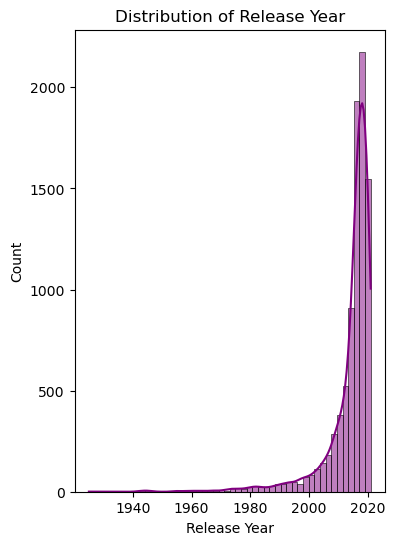

```python
plt.figure(figsize=(4,6))
sns.histplot(data=df_new,x="release_year",bins=50,color="purple",kde=True)
plt.title("Distribution of Release Year")
plt.xlabel("Release Year")
plt.show()
```

- The histogram shows the distribution of release year
- A huge majority of the releases happened in the last 10-15 years.
- There are very few releases from before the year 2000.
- The no.of releases started growing very fast after 2010.
- 2018 and 2019 were the biggest year of releases.
- The numbers drop suddenly after 2019
- The distribution is strongly left-skewed
- Most of the data is crowded on the right side (recent years)

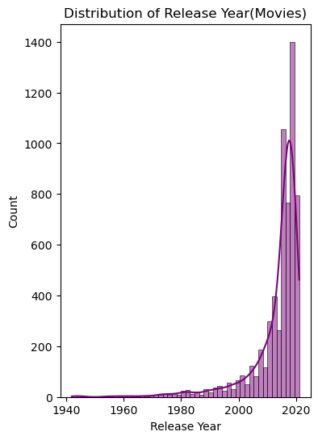

```python
plt.figure(figsize=(4,6))
sns.histplot(data=df_new1,x="release_year",bins=50,color="purple",kde=True)
plt.title("Distribution of Release Year(Movies)")
plt.xlabel("Release Year")
plt.show()
```

- Most content is released after 2000
- Majority of release happened in 10-15 years
- Releases from 1940 to 1980 are very rare
- There is a massive spike right around 2018
- After 2018 peak,there is a quick decline in the no.of releases in leading into 2020

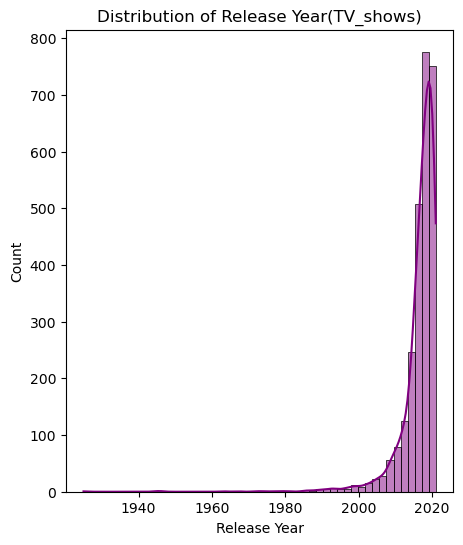

```python
plt.figure(figsize=(5,6))
sns.histplot(data=df_new2,x="release_year",bins=50,color="purple",kde=True)
plt.title("Distribution of Release Year(TV_shows)")
plt.xlabel("Release Year")
plt.show()
```

### **Box Plot**

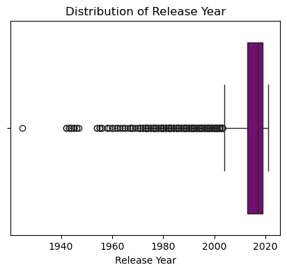

```python
plt.figure(figsize=(5,4))
sns.boxplot(data=df_new,x="release_year",color="purple")
plt.title("Distribution of Release Year")
plt.xlabel("Release Year")
plt.show()
```

- 50% of all releases happened between approximately 2013 and 2019
- The vertical line in the box shows the middle value is around 2017
- The long trail of circles to the left shows that releases before 2005 are rare and considered outliers

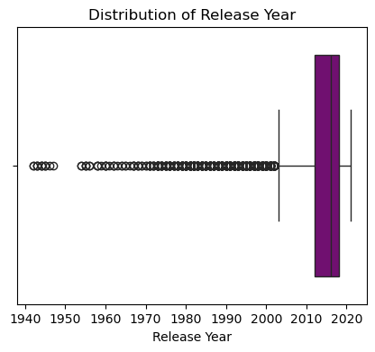

```python
plt.figure(figsize=(5,4))
sns.boxplot(data=df_new1,x="release_year",color="purple")
plt.title("Distribution of Release Year")
plt.xlabel("Release Year")
plt.show()
```

- Most data is concentrated in 2010–2020
- The distribution is skewed toward recent years
- Many older years appear as outliers
- The median is in recent years
- Very few entries before 2000

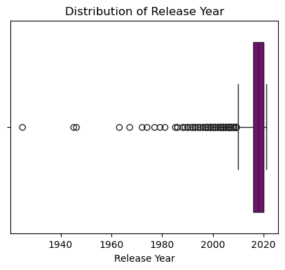

```python
plt.figure(figsize=(5,4))
sns.boxplot(data=df_new2,x="release_year",color="purple")
plt.title("Distribution of Release Year")
plt.xlabel("Release Year")
plt.show()
```

- Most titles are recent: the catalog is heavily weighted toward releases after 2010.
- Movies dominate the dataset over TV shows.
- Adult-rated content is the largest rating group.
- Netflix content peaks around 2018–2019 and drops after 2019.
- TV shows are usually short-run (1–3 seasons) in this dataset.
- Older releases (pre-2000) are rare and appear as outliers.

### **Count Plot**

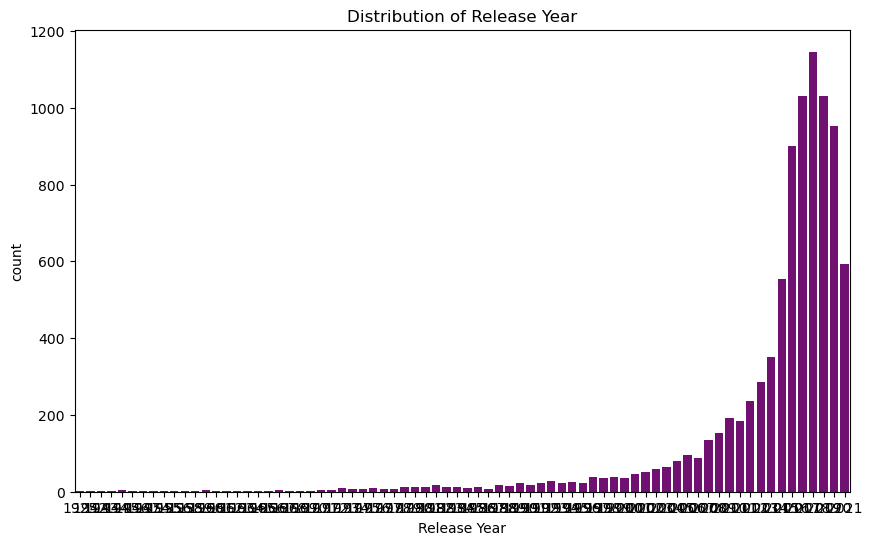

```python
plt.figure(figsize=(10,6))
sns.countplot(data=df_new,x="release_year",color="purple")
plt.title("Distribution of Release Year")
plt.xlabel("Release Year")
plt.show()
```

- Most releaes are after 2010
- there is only very few releases before 2000
- Release increases quickly after 2010
- The highest releases count are in 2018–2019
- After 2019, counts drop a bit
- The data is right-heavy, meaning recent years dominate

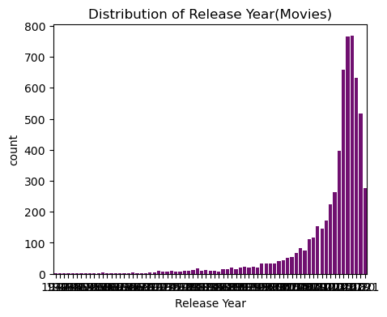

```python
plt.figure(figsize=(5,4))
sns.countplot(data=df_new1,x="release_year",color="purple")
plt.title("Distribution of Release Year(Movies)")
plt.xlabel("Release Year")
plt.show()
```

- Most titles are from 2010 onward.
- Movies far outnumber TV shows.
- Adult-rated content is the largest group.
- Release volume peaks around 2018–2019.

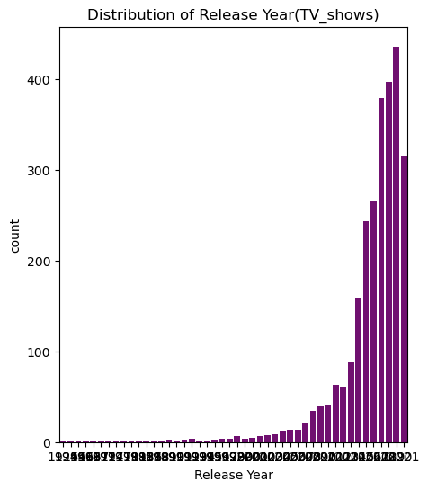

```python
plt.figure(figsize=(5,6))
sns.countplot(data=df_new2,x="release_year",color="purple")
plt.title("Distribution of Release Year(TV_shows)")
plt.xlabel("Release Year")
plt.show()
```

- Most catalog entries are recent (after 2010).
- Movies dominate over TV shows.
- Adult-rated content is the largest group.

### **Pie Chart**

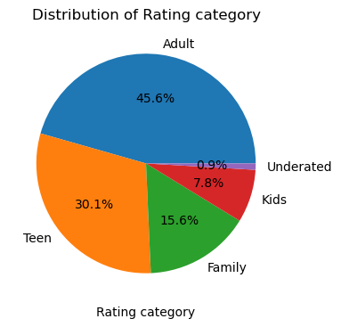

```python
x=df_new['rating_category'].value_counts()
labels=['Adult','Teen','Family','Kids','Underated']
plt.figure(figsize=(5,4))
plt.pie(x,labels=labels,autopct='%1.1f%%')
plt.title("Distribution of Rating category")
plt.xlabel("Rating category")
plt.show()
```

- This pie chart shows how many titles are in each rating group.
- **Adult** is the biggest group, so most titles are for mature viewers.
- **Teen** is the next biggest group.
- **Family** and **Kids** are smaller, so child-friendly content is less common.
- **Unrated** titles are very few.

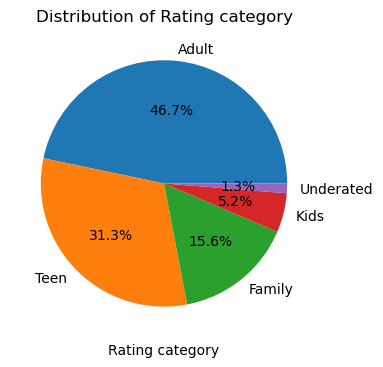

```python
x=df_new1['rating_category'].value_counts()
labels=['Adult','Teen','Family','Kids','Underated']
plt.figure(figsize=(5,4))
plt.pie(x,labels=labels,autopct='%1.1f%%')
plt.title("Distribution of Rating category")
plt.xlabel("Rating category")
plt.show()
```

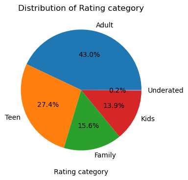

```python
x=df_new2['rating_category'].value_counts()
labels=['Adult','Teen','Family','Kids','Underated']
plt.figure(figsize=(5,4))
plt.pie(x,labels=labels,autopct='%1.1f%%')
plt.title("Distribution of Rating category")
plt.xlabel("Rating category")
plt.show()
```

## **Bivariate Analysis**

#### **Bar Plot**

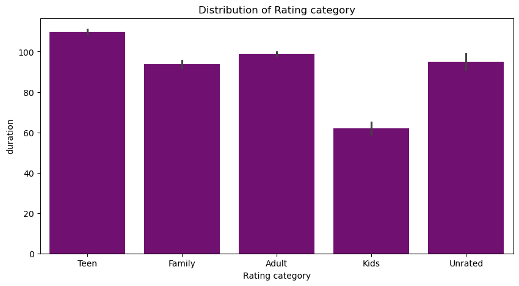

```python
plt.figure(figsize=(10,5))
sns.barplot(data=df_new1,x="rating_category",y="duration",color="purple")
plt.title("Distribution of Rating category")
plt.xlabel("Rating category")
plt.show()
```

- The bar plot shows average length for each rating group.
- **Teen** and **Adult** categories have the longest durations.
- **Kids** content is much shorter than other groups.

#### **Line Plot**

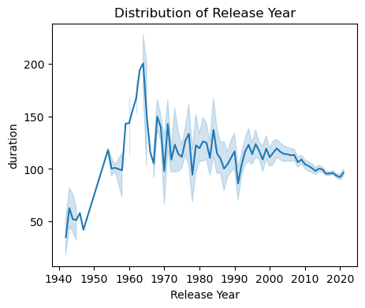

```python
plt.figure(figsize=(5,4))
sns.lineplot(data=df_new1,x="release_year",y=("duration"))
plt.title("Distribution of Release Year")
plt.xlabel("Release Year")
plt.show()
```

- Movie lengths increased sharply from the 1940s to the mid-1960s
- Peak average duration occurred around the 1960s
- High variability in movie lengths during the 1960s–1980s
- Gradual decline in duration after the 1970s
- Modern films (2000s onward) are shorter and more consistent
- Overall trend: rise → peak → steady decline → stabilization

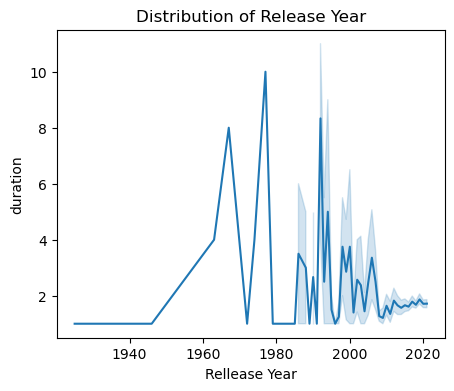

```python
plt.figure(figsize=(5,4))
sns.lineplot(data=df_new2,x="release_year",y=("duration"))
plt.title("Distribution of Release Year")
plt.xlabel("Rellease Year")
plt.show()
```

- Values stay very low and flat until around the 1950s
- Sharp spikes appear between the 1960s–1980s (high instability)
- Peak occurs around the late 1970s–early 1980s
- After 1990, values drop and fluctuate frequently
- From 2000 onward, values stabilize at low levels
- Overall trend: flat → volatile spikes → decline → low, stable pattern

#### **Scatter Plot**

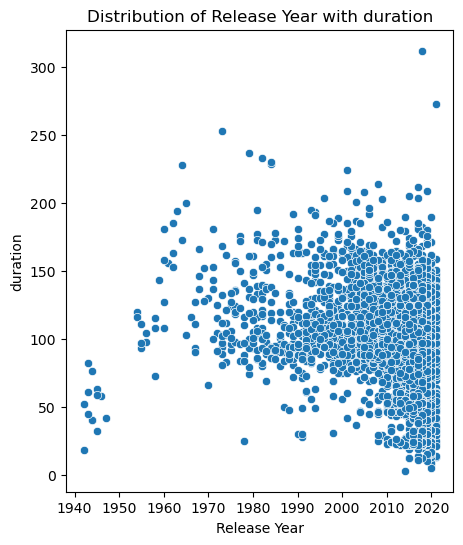

```python
plt.figure(figsize=(5,6))
sns.scatterplot(data=df_new1,x="release_year",y=("duration"))
plt.title("Distribution of Release Year with duration")
plt.xlabel("Release Year")
plt.show()
```

- Most movies cluster between ~80–150 minutes
- After 2000, many more movies are released (denser points)
- Wide spread in durations, but majority stay in mid-range
- Some outliers: very short (<50 min) and very long (>200 min) films
- Older films (pre-1970) are fewer but often longer
- Overall: high variation, but typical movie length stays around ~100–140 minutes

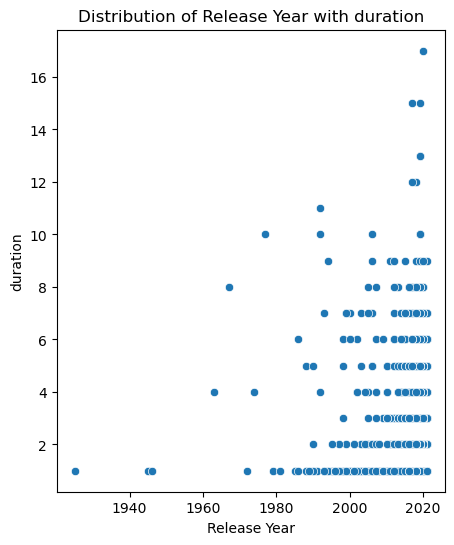

```python
plt.figure(figsize=(5,6))
sns.scatterplot(data=df_new2,x="release_year",y=("duration"))
plt.title("Distribution of Release Year with duration")
plt.xlabel("Release Year")
plt.show()
```

- Most TV shows are of smaller duration(1-3 seasons)
- The number of releases increases very much after 2010.
- Very long-running shows (duration above 10) are rare and appear as outliers.
- The plot suggests Netflix content is skewed toward newer, shorter-run TV = - shows rather than long multi-season series.

DAY-6

## **Multivariate Analysis**

#### **HeatMap**

```python
df_new1_num=df_new1.select_dtypes(include='number')
df_new1_num.corr()
```

|  | release_year | duration |
| --- | --- | --- |
| release_year | 1.000000 | -0.206248 |
| duration | -0.206248 | 1.000000 |

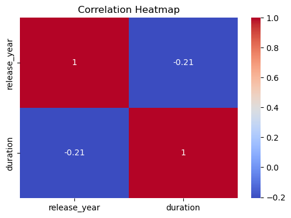

```python
plt.figure(figsize=(6,4))
sns.heatmap(df_new1.corr(numeric_only=True), annot=True, cmap="coolwarm")
plt.title("Correlation Heatmap")
plt.show()
```

- The correlation between release_year and duration is -0.21.
- This is a weak negative relationship → as release year increases, duration tends to slightly decrease.
- The value is close to 0, so the relationship is not strong.
- This means newer content is only slightly shorter on average, but not by much.
- There is no strong pattern between release year and duration.

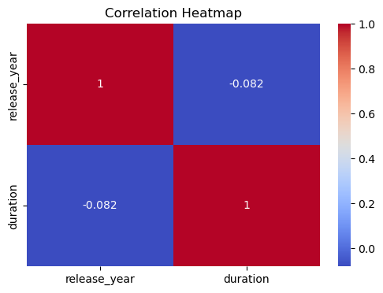

```python
plt.figure(figsize=(6,4))
sns.heatmap(df_new2.corr(numeric_only=True),annot=True, cmap="coolwarm")
plt.title("Correlation Heatmap")
plt.show()
```

#### **Pair Plot**

[output not shown]

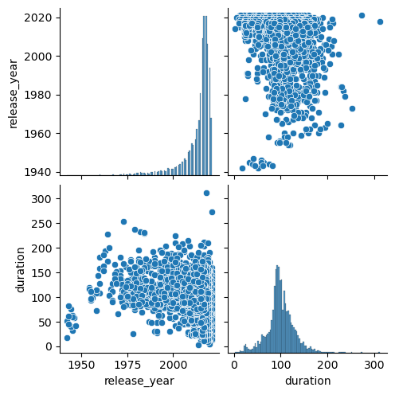

```python
plt.figure(figsize=(6,4))
sns.pairplot(df_new1.select_dtypes(include='number'), palette='coolwarm')
```

- The pairplot shows no strong linear relationship between release_year and duration.
- Points are scattered widely, so newer movies are not consistently longer or shorter.
- Most movies cluster around typical durations, regardless of release year.
- The trend is almost flat, confirming the weak negative correlation.

[output not shown]

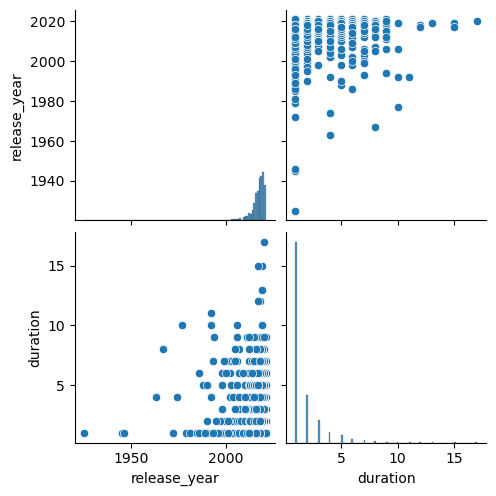

```python
plt.figure(figsize=(6,4))
sns.pairplot(df_new2.select_dtypes(include='number'), palette='coolwarm')
```

- most releases are from 2010 onward.
- peak release activity is around 2018–2019.
- Movies dominate the dataset.TV shows are fewer and mostly short-run.
- Ratings are skewed toward adult content, with teen content second-largest.
- TV show durations are mostly 1–3 seasons; long series are rare.
- Release year vs duration shows only a weak negative correlation.

DAY-7

### **CONCLUSION**

In this project, the Netflix Dataset was successfully cleaned and analyzed. Several changes were made to improve the quality of the data. Missing values in columns like director, cast, and country were handled by filling or removing them.The movies and tv shows are seperated to a file. The duration column was cleaned and converted into a proper numeric format, where movies are shown in minutes and TV shows in seasons.

After cleaning, the dataset became more accurate and easy to use for analysis. The analysis showed that Netflix has more movies than TV shows, most content is released after 2010, and popular genres include drama and comedy. It also showed that content is mainly made for young and adult audiences.

Overall, this project helped in understanding how to clean data, fix errors, and perform data analysis. It shows the importance of data preprocessing before doing any analysis.